# Classification (Supervised Learning): Logistic Regression

Mary Solomon

2/9/2021

load the functions

```r
source("thesis_functions.R")
```

set levels of ordinal data, and other variables to their appropriate dataypes. Did not adjust the datatypes for date/time since those will not be used in this portion

```r
data <- fread("kpopdata.csv")
data <- mutate(data, ArtistType = as.factor(ArtistType),
               ArtistGender = as.factor(ArtistGender),
               ArtistGen = factor(ArtistGen),
               #release_date = as.POSIXct.Date(release_date),
               key = factor(key, levels = 0:11),
               mode = as.factor(mode),
               time_signature = factor(time_signature, levels = c(1,3,4,5)))
data$newgen <- as.factor(ifelse(data$ArtistGen == 3 | data$ArtistGen == 4, 1, 0))
```

Time signature is out since almost all are 4/4 time. Analysis will also be split up into two binary logistic regression models which will predict for songs where mode = 0 and those where mode = 1

Personal predictions: I believe popularity will be a strong predictor since the popularity measure is also time dependent.

# Assumptions of the logistic Model

# Logistic: predict which songs are old gen (1 & 2) vs new gen (3 & 4)

Create Train(70%), Valid(15%), and Test(15%) Data

```r
kpop <- select(data, newgen, popularity, duration, acousticness, danceability, energy, instrumentalness, key, loudness, mode, speechiness, tempo, valence)
kpop0 <- kpop %>% filter(mode == 0)%>% select(-mode)
kpop1 <- kpop %>% filter(mode == 1) %>% select(-mode)

# Mode0: Train/Valid/Test
set.seed(123)
p3.0 <- partition.3(kpop0, 0.70, 0.15)
train0 <- p3.0$data.train
valid0 <- p3.0$data.val
test0 <- p3.0$data.test
all.train0 <- rbind(train0, valid0)

# Mode1: Train/Valid/Test
set.seed(123)
p3.1 <- partition.3(kpop1, 0.70, 0.15)
train1 <- p3.1$data.train
valid1 <- p3.1$data.val
test1 <- p3.1$data.test
all.train1 <- rbind(train1, valid1)
```

## Logistic Where mode = 0

Minor key

Full logistic model

```r
set.seed(123)
logit0 <- glm(newgen ~., data = train0, family = "binomial")
summary(logit0)
```

```
##
## Call:
## glm(formula = newgen ~ ., family = "binomial", data = train0)
##
## Deviance Residuals:
##     Min       1Q   Median       3Q      Max
## -2.5652  -0.7153  -0.3725   0.7715   2.4990
##
## Coefficients:
##                   Estimate Std. Error z value Pr(>|z|)
## (Intercept)       0.176539   0.841527   0.210   0.8338
## popularity        0.073492   0.002982  24.642  < 2e-16 ***
## duration         -0.008926   0.001576  -5.662 1.49e-08 ***
## acousticness      1.352971   0.310940   4.351 1.35e-05 ***
## danceability      0.689603   0.496092   1.390   0.1645
## energy            0.403242   0.546153   0.738   0.4603
## instrumentalness  2.725461   0.613772   4.441 8.97e-06 ***
## key1              0.190816   0.217415   0.878   0.3801
## key2              0.144636   0.271669   0.532   0.5945
## key3             -0.504102   0.322027  -1.565   0.1175
## key4             -0.273304   0.220964  -1.237   0.2161
## key5             -0.189942   0.209593  -0.906   0.3648
## key6             -0.126234   0.216226  -0.584   0.5594
## key7              0.549019   0.236524   2.321   0.0203 *
## key8             -0.181322   0.264434  -0.686   0.4929
## key9             -0.291911   0.227882  -1.281   0.2002
## key10            -0.277182   0.231487  -1.197   0.2312
## key11            -0.091329   0.203465  -0.449   0.6535
## loudness          0.218762   0.038797   5.639 1.71e-08 ***
## speechiness       1.736218   0.713427   2.434   0.0149 *
## tempo            -0.002087   0.001884  -1.108   0.2679
## valence          -1.307845   0.272565  -4.798 1.60e-06 ***
## ---
## Signif. codes:  0 '***' 0.001 '**' 0.01 '*' 0.05 '.' 0.1 ' ' 1
##
## (Dispersion parameter for binomial family taken to be 1)
##
##     Null deviance: 4370.7  on 3270  degrees of freedom
## Residual deviance: 3130.2  on 3249  degrees of freedom
## AIC: 3174.2
##
## Number of Fisher Scoring iterations: 5
```

find optimal cut off value

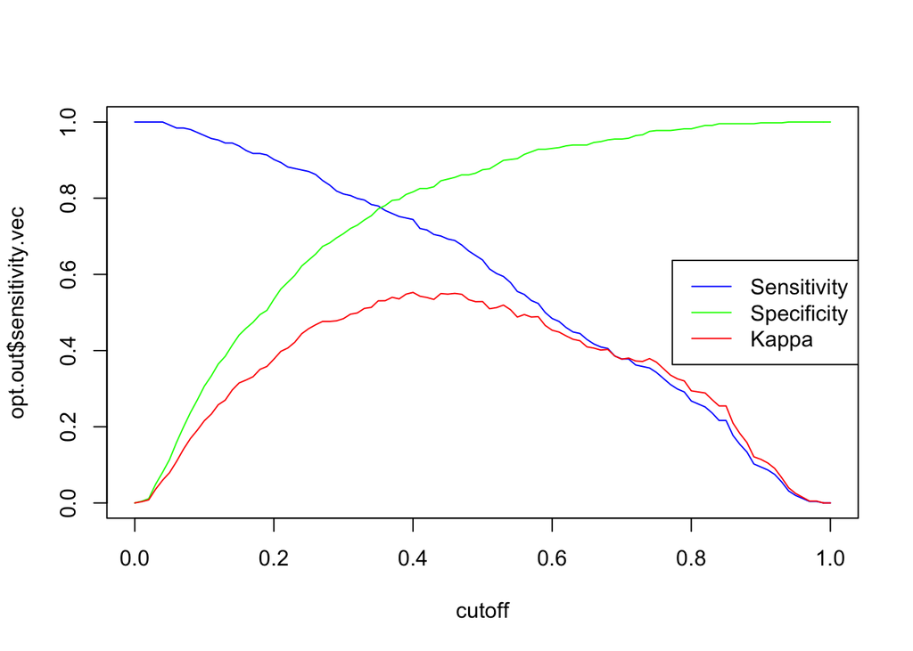

```r
logit.out0 <- opt.cut.genn(logit0, valid0)
opt.cut.plot(logit.out0)
```

```r
#optimal by kappa score
logit.out0$cutoff[which.max(logit.out0$kappa.vec)]
```

```
## [1] 0.4
```

```r
#optimal by sensitivity/specificity balance
logit.out0$cutoff[which.min(logit.out0$ssdiff.vec)]
```

```
## [1] 0.35
```

Final full logistic model fit to the combo of train and validation data.

```r
set.seed(123)
logit0.final <- glm(newgen ~., data = all.train0, family = "binomial")
summary(logit0.final)
```

```
##
## Call:
## glm(formula = newgen ~ ., family = "binomial", data = all.train0)
##
## Deviance Residuals:
##     Min       1Q   Median       3Q      Max
## -2.6484  -0.7156  -0.3739   0.7632   2.5128
##
## Coefficients:
##                   Estimate Std. Error z value Pr(>|z|)
## (Intercept)       0.453378   0.765547   0.592 0.553699
## popularity        0.073963   0.002729  27.107  < 2e-16 ***
## duration         -0.008866   0.001423  -6.230 4.67e-10 ***
## acousticness      1.279719   0.280453   4.563 5.04e-06 ***
## danceability      0.714916   0.455608   1.569 0.116614
## energy            0.227497   0.497651   0.457 0.647569
## instrumentalness  2.789963   0.569823   4.896 9.77e-07 ***
## key1              0.301071   0.198782   1.515 0.129880
## key2              0.241643   0.247045   0.978 0.328010
## key3             -0.540052   0.296559  -1.821 0.068597 .
## key4             -0.307942   0.203424  -1.514 0.130078
## key5             -0.253116   0.193303  -1.309 0.190391
## key6             -0.148084   0.198377  -0.746 0.455379
## key7              0.498376   0.218746   2.278 0.022707 *
## key8             -0.194073   0.239876  -0.809 0.418484
## key9             -0.269600   0.208467  -1.293 0.195926
## key10            -0.307252   0.211239  -1.455 0.145802
## key11            -0.075316   0.187941  -0.401 0.688608
## loudness          0.236009   0.035790   6.594 4.28e-11 ***
## speechiness       2.169906   0.654692   3.314 0.000918 ***
## tempo            -0.002942   0.001710  -1.720 0.085468 .
## valence          -1.358594   0.248376  -5.470 4.50e-08 ***
## ---
## Signif. codes:  0 '***' 0.001 '**' 0.01 '*' 0.05 '.' 0.1 ' ' 1
##
## (Dispersion parameter for binomial family taken to be 1)
##
##     Null deviance: 5290.4  on 3971  degrees of freedom
## Residual deviance: 3771.2  on 3950  degrees of freedom
## AIC: 3815.2
##
## Number of Fisher Scoring iterations: 5
```

Full Logistic model
$$log(\frac{\hat \pi}{1 - \hat \pi}) = 0.453 + 0.074x_{Popularity} - 0.009x_{Duration} + 1.280x_{Acousticness} + 0.715x_{Danceability}
\\ + 0.227x_{Energy} + 2.790x_{Instrumentalness} + 0.301x_{Key1} + 0.242x_{Key2}
\\ - 0.540x_{Key3} - 0.308x_{Key4} - 0.253x_{Key5} - 0.148x_{Key6} + 0.498x_{Key7}
\\ - 0.194x_{Key8} - 0.270x_{Key9} - 0.307x_{Key10} - 0.075x_{Key11} + 0.236x_{Loudness}
\\ + 2.170x_{Speechiness} - 0.003x_{Tempo} - 1.359x_{Valence}$$

The audio features in this model that increase the odds of being categorized as a new generation kpop song multiplicativley are Popularity, Acousticness, Danceability, Energy, Instrumentalness, Loudness, Speechiness and choosing Key1(C#/D-flat minor), Key2(D minor), Key7(G minor) instead of Key0 (C minor). The features that decrease the odds multiplicatively of being categorized as a new generation kpop song are Duration, Tempo, Valence and choosing Key3(D#/E-flat Minor), Key4(E minor), Key5(F Minor), Key6(F#/G-flat Minor), Key8 (G#/A-flat minor), Key9(A minor), Key10(A#/B-flat minor), Key11(B minor) instead of Key0(C).

Only the variables Popularity, Duration, Acousticness, Instrumentalness, Key7(G minor), Loudness, Speechiness, and Valence are significant predictors in contributing to the log of odds for categorizing a song into the newer generations of kpop versus the older generation.

confusion matrix on the training data:

```
logit.train0.pred <- logit0$fitted.values
logit.train0.y <- ifelse(logit.train0.pred > 0.5, 1, 0) # using cutoff = 0.5
confusionMatrix(as.factor(logit.train0.y), as.factor(train0$newgen),
                positive = "1")
```

confusion matrix on the test data using standard cut off

```r
#get predicted probabilities for the test data
logit.test0.pred <- predict(logit0.final, newdata = test0, type = "response")
logit.test0.y <- ifelse(logit.test0.pred > 0.5, 1, 0) # using cutoff = 0.5
confusionMatrix(as.factor(logit.test0.y), as.factor(test0$newgen),
                positive = "1")
```

```
## Confusion Matrix and Statistics
##
##           Reference
## Prediction   0   1
##          0 364 105
##          1  64 168
##
##                Accuracy : 0.7589
##                  95% CI : (0.7255, 0.7901)
##     No Information Rate : 0.6106
##     P-Value [Acc > NIR] : < 2.2e-16
##
##                   Kappa : 0.4789
##
##  Mcnemar's Test P-Value : 0.002091
##
##             Sensitivity : 0.6154
##             Specificity : 0.8505
##          Pos Pred Value : 0.7241
##          Neg Pred Value : 0.7761
##              Prevalence : 0.3894
##          Detection Rate : 0.2397
##    Detection Prevalence : 0.3310
##       Balanced Accuracy : 0.7329
##
##        'Positive' Class : 1
##
```

confusion matrix on the test data using optimal cutoff based on kappa (0.40)

```r
#get predicted probabilities for the test data
logit.test0.pred <- predict(logit0.final, newdata = test0, type = "response")
logit.test0.y <- ifelse(logit.test0.pred > 0.40, 1, 0) # using cutoff = 0.40
confusionMatrix(as.factor(logit.test0.y), as.factor(test0$newgen),
                positive = "1")
```

```
## Confusion Matrix and Statistics
##
##           Reference
## Prediction   0   1
##          0 332  83
##          1  96 190
##
##                Accuracy : 0.7447
##                  95% CI : (0.7107, 0.7766)
##     No Information Rate : 0.6106
##     P-Value [Acc > NIR] : 4.68e-14
##
##                   Kappa : 0.4676
##
##  Mcnemar's Test P-Value : 0.3698
##
##             Sensitivity : 0.6960
##             Specificity : 0.7757
##          Pos Pred Value : 0.6643
##          Neg Pred Value : 0.8000
##              Prevalence : 0.3894
##          Detection Rate : 0.2710
##    Detection Prevalence : 0.4080
##       Balanced Accuracy : 0.7358
##
##        'Positive' Class : 1
##
```

confusion matrix on the test data using optimal cutoff based on sensitivity/specificty balance (0.35)

```r
#get predicted probabilities for the test data
logit.test0.pred <- predict(logit0.final, newdata = test0, type = "response")
logit.test0.y <- ifelse(logit.test0.pred > 0.35, 1, 0) # using cutoff = 0.35
confusionMatrix(as.factor(logit.test0.y), as.factor(test0$newgen),
                positive = "1")
```

```
## Confusion Matrix and Statistics
##
##           Reference
## Prediction   0   1
##          0 308  78
##          1 120 195
##
##                Accuracy : 0.7175
##                  95% CI : (0.6826, 0.7506)
##     No Information Rate : 0.6106
##     P-Value [Acc > NIR] : 1.909e-09
##
##                   Kappa : 0.4222
##
##  Mcnemar's Test P-Value : 0.003571
##
##             Sensitivity : 0.7143
##             Specificity : 0.7196
##          Pos Pred Value : 0.6190
##          Neg Pred Value : 0.7979
##              Prevalence : 0.3894
##          Detection Rate : 0.2782
##    Detection Prevalence : 0.4494
##       Balanced Accuracy : 0.7170
##
##        'Positive' Class : 1
##
```

### Variable Selection: Stepwise

stepwise

```r
set.seed(123)
logit0.none <- glm(newgen ~ 1, data = train0, family = binomial)
step0 <- step(logit0.none,
                 list(lower=formula(logit0.none), upper = formula(logit0)),
                 direction = "both",
                 trace=0)
formula(step0)
```

```
## newgen ~ popularity + duration + loudness + valence + acousticness +
##     instrumentalness + key + speechiness + danceability
```

```r
summary(step0)
```

```
##
## Call:
## glm(formula = newgen ~ popularity + duration + loudness + valence +
##     acousticness + instrumentalness + key + speechiness + danceability,
##     family = binomial, data = train0)
##
## Deviance Residuals:
##     Min       1Q   Median       3Q      Max
## -2.5385  -0.7193  -0.3730   0.7703   2.4937
##
## Coefficients:
##                   Estimate Std. Error z value Pr(>|z|)
## (Intercept)       0.253030   0.554006   0.457   0.6479
## popularity        0.073178   0.002942  24.872  < 2e-16 ***
## duration         -0.008930   0.001578  -5.661 1.50e-08 ***
## loudness          0.233697   0.031267   7.474 7.76e-14 ***
## valence          -1.291818   0.263451  -4.903 9.42e-07 ***
## acousticness      1.266046   0.272732   4.642 3.45e-06 ***
## instrumentalness  2.741099   0.609355   4.498 6.85e-06 ***
## key1              0.183659   0.217029   0.846   0.3974
## key2              0.138257   0.271780   0.509   0.6110
## key3             -0.512165   0.321903  -1.591   0.1116
## key4             -0.269833   0.220893  -1.222   0.2219
## key5             -0.192689   0.209292  -0.921   0.3572
## key6             -0.132849   0.215687  -0.616   0.5379
## key7              0.545226   0.236436   2.306   0.0211 *
## key8             -0.183017   0.264006  -0.693   0.4882
## key9             -0.291443   0.227568  -1.281   0.2003
## key10            -0.279755   0.231273  -1.210   0.2264
## key11            -0.095537   0.203228  -0.470   0.6383
## speechiness       1.751742   0.699392   2.505   0.0123 *
## danceability      0.795588   0.476200   1.671   0.0948 .
## ---
## Signif. codes:  0 '***' 0.001 '**' 0.01 '*' 0.05 '.' 0.1 ' ' 1
##
## (Dispersion parameter for binomial family taken to be 1)
##
##     Null deviance: 4370.7  on 3270  degrees of freedom
## Residual deviance: 3131.9  on 3251  degrees of freedom
## AIC: 3171.9
##
## Number of Fisher Scoring iterations: 5
```

find optimal cut off value

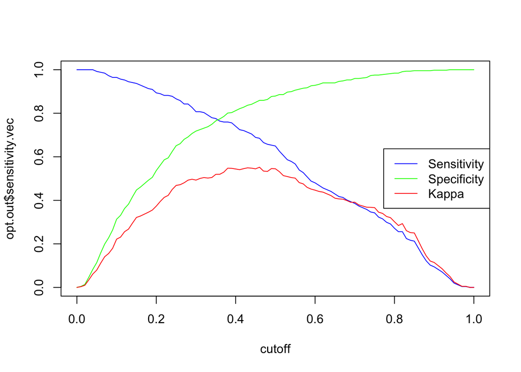

```r
step.out0 <- opt.cut.genn(step0, valid0)
opt.cut.plot(step.out0)
```

```r
#optimal by kappa score
step.out0$cutoff[which.max(step.out0$kappa.vec)]
```

```
## [1] 0.46
```

```r
#optimal by sensitivity/specificity balance
step.out0$cutoff[which.min(step.out0$ssdiff.vec)]
```

```
## [1] 0.36
```

final stepwise model

```r
set.seed(123)
logit0.none <- glm(newgen ~ 1, data = all.train0, family = binomial)
step0.final <- step(logit0.none,
                 list(lower=formula(logit0.none), upper = formula(logit0)),
                 direction = "both",
                 trace=0)
formula(step0.final)
```

```
## newgen ~ popularity + duration + loudness + valence + acousticness +
##     instrumentalness + key + speechiness + tempo + danceability
```

```r
summary(step0.final)
```

```
##
## Call:
## glm(formula = newgen ~ popularity + duration + loudness + valence +
##     acousticness + instrumentalness + key + speechiness + tempo +
##     danceability, family = binomial, data = all.train0)
##
## Deviance Residuals:
##     Min       1Q   Median       3Q      Max
## -2.6540  -0.7136  -0.3748   0.7629   2.5168
##
## Coefficients:
##                   Estimate Std. Error z value Pr(>|z|)
## (Intercept)       0.684438   0.575289   1.190 0.234153
## popularity        0.073773   0.002695  27.372  < 2e-16 ***
## duration         -0.008871   0.001424  -6.229 4.69e-10 ***
## loudness          0.245953   0.028509   8.627  < 2e-16 ***
## valence          -1.331118   0.240965  -5.524 3.31e-08 ***
## acousticness      1.220727   0.248912   4.904 9.38e-07 ***
## instrumentalness  2.807384   0.568985   4.934 8.06e-07 ***
## key1              0.297959   0.198686   1.500 0.133705
## key2              0.240189   0.247124   0.972 0.331084
## key3             -0.545008   0.296357  -1.839 0.065911 .
## key4             -0.307534   0.203471  -1.511 0.130678
## key5             -0.255709   0.193235  -1.323 0.185735
## key6             -0.152897   0.198095  -0.772 0.440212
## key7              0.497174   0.218712   2.273 0.023015 *
## key8             -0.197091   0.239737  -0.822 0.411012
## key9             -0.270581   0.208453  -1.298 0.194272
## key10            -0.309520   0.211151  -1.466 0.142683
## key11            -0.076322   0.187929  -0.406 0.684655
## speechiness       2.213792   0.647156   3.421 0.000624 ***
## tempo            -0.002918   0.001709  -1.708 0.087679 .
## danceability      0.694840   0.453367   1.533 0.125369
## ---
## Signif. codes:  0 '***' 0.001 '**' 0.01 '*' 0.05 '.' 0.1 ' ' 1
##
## (Dispersion parameter for binomial family taken to be 1)
##
##     Null deviance: 5290.4  on 3971  degrees of freedom
## Residual deviance: 3771.4  on 3951  degrees of freedom
## AIC: 3813.4
##
## Number of Fisher Scoring iterations: 5
```

Stepwise Logistic Model:

In comparison to the full model, the variable energy is not included. Otherwise, many of the coefficients are very similar to that of the full model.

$$log(\frac{\hat \pi}{1 - \hat \pi}) = 0.684 + 0.074_{Popularity} - 0.009_{Duration} + 1.221_{Acousticness}
\\ + 0.695_{Danceability} + 2.807_{Instrumentalness} + 0.298_{Key1} + 0.240_{Key2}
\\ - 0.545_{Key3} - 0.308x_{Key4} - 0.256x_{Key5} - 0.153_{Key6} + 0.497_{Key7}
\\ - 0.197_{Key8} - 0.271_{Key9} - 0.310_{Key10} - 0.076_{Key11} + 0.246_{Loudness}
\\ + 2.214_{Speechiness} - 0.003_{Tempo} - 1.331_{Valence}$$

The audio features in this model that increase the odds of being categorized as a new generation kpop song multiplicativley are Popularity, Acousticness, Danceability, Instrumentalness, Loudness, Speechiness and choosing Key1(C#/D-flat minor), Key2(D minor), Key7(G minor) instead of Key0 (C minor). The features that decrease the odds multiplicatively of being categorized as a new generation kpop song are Duration, Tempo, Valence and choosing Key3(D#/E-flat Minor), Key4(E minor), Key5(F Minor), Key6(F#/G-flat Minor), Key8 (G#/A-flat minor), Key9(A minor), Key10(A#/B-flat minor), Key11(B minor) instead of Key0(C).

Only the variables Popularity, Duration, Acousticness, Instrumentalness, Key7(G minor), Loudness, Speechiness, and Valence are significant predictors in contributing to the log of odds for categorizing a song into the newer generations of kpop versus the older generation. These significant variables are the same as the full model.

confusion matrix on the training data:

```
step.train0.pred <- step0$fitted.values
step.train0.y <- ifelse(step.train0.pred > 0.5, 1, 0) # using cutoff = 0.5
confusionMatrix(as.factor(step.train0.y), as.factor(train0$newgen),
                positive = "1")
```

predict and evaluate on test using standard cut off 0.5

```r
#get predicted probabilities for the test data
step.test0.pred <- predict(step0.final, newdata = test0, type = "response")
step.test0.y <- ifelse(step.test0.pred > 0.5, 1, 0) # using cutoff = 0.5
confusionMatrix(as.factor(step.test0.y), as.factor(test0$newgen),
                positive = "1")
```

```
## Confusion Matrix and Statistics
##
##           Reference
## Prediction   0   1
##          0 364 105
##          1  64 168
##
##                Accuracy : 0.7589
##                  95% CI : (0.7255, 0.7901)
##     No Information Rate : 0.6106
##     P-Value [Acc > NIR] : < 2.2e-16
##
##                   Kappa : 0.4789
##
##  Mcnemar's Test P-Value : 0.002091
##
##             Sensitivity : 0.6154
##             Specificity : 0.8505
##          Pos Pred Value : 0.7241
##          Neg Pred Value : 0.7761
##              Prevalence : 0.3894
##          Detection Rate : 0.2397
##    Detection Prevalence : 0.3310
##       Balanced Accuracy : 0.7329
##
##        'Positive' Class : 1
##
```

predict and evaluate on test using optimal cut off 0.46 for highest kappa

```r
#get predicted probabilities for the test data
step.test0.pred <- predict(step0.final, newdata = test0, type = "response")
step.test0.y <- ifelse(step.test0.pred > 0.46, 1, 0) # using cutoff = 0.46
confusionMatrix(as.factor(step.test0.y), as.factor(test0$newgen),
                positive = "1")
```

```
## Confusion Matrix and Statistics
##
##           Reference
## Prediction   0   1
##          0 354  97
##          1  74 176
##
##                Accuracy : 0.7561
##                  95% CI : (0.7225, 0.7874)
##     No Information Rate : 0.6106
##     P-Value [Acc > NIR] : 2.439e-16
##
##                   Kappa : 0.4791
##
##  Mcnemar's Test P-Value : 0.09249
##
##             Sensitivity : 0.6447
##             Specificity : 0.8271
##          Pos Pred Value : 0.7040
##          Neg Pred Value : 0.7849
##              Prevalence : 0.3894
##          Detection Rate : 0.2511
##    Detection Prevalence : 0.3566
##       Balanced Accuracy : 0.7359
##
##        'Positive' Class : 1
##
```

predict and evaluate on test using optimal cut off 0.36 for best sensitivity/specificity balance

```r
#get predicted probabilities for the test data
step.test0.pred <- predict(step0.final, newdata = test0, type = "response")
step.test0.y <- ifelse(step.test0.pred > 0.36, 1, 0) # using cutoff = 0.36
confusionMatrix(as.factor(step.test0.y), as.factor(test0$newgen),
                positive = "1")
```

```
## Confusion Matrix and Statistics
##
##           Reference
## Prediction   0   1
##          0 314  79
##          1 114 194
##
##                Accuracy : 0.7247
##                  95% CI : (0.69, 0.7575)
##     No Information Rate : 0.6106
##     P-Value [Acc > NIR] : 1.496e-10
##
##                   Kappa : 0.4342
##
##  Mcnemar's Test P-Value : 0.01439
##
##             Sensitivity : 0.7106
##             Specificity : 0.7336
##          Pos Pred Value : 0.6299
##          Neg Pred Value : 0.7990
##              Prevalence : 0.3894
##          Detection Rate : 0.2767
##    Detection Prevalence : 0.4394
##       Balanced Accuracy : 0.7221
##
##        'Positive' Class : 1
##
```

### Variable Selection: Stepwise (10 fold CV)

step-wise 10 fold cross validation

```r
set.seed(123)
train_control <- trainControl(method = "cv",
                              number = 10)

# Fit K-fold CV model
bye <- capture.output(step0_kcv <- train(newgen ~ ., data = train0, family = "binomial",
                 method = "glmStepAIC", trControl = train_control, verbose = FALSE))
```

```r
step0_kcv <- step0_kcv$finalModel
summary(step0_kcv)
```

```
##
## Call:
## NULL
##
## Deviance Residuals:
##     Min       1Q   Median       3Q      Max
## -2.5372  -0.7250  -0.3770   0.7722   2.5272
##
## Coefficients:
##                   Estimate Std. Error z value Pr(>|z|)
## (Intercept)       0.082704   0.532543   0.155   0.8766
## popularity        0.073019   0.002928  24.939  < 2e-16 ***
## duration         -0.008964   0.001572  -5.702 1.18e-08 ***
## acousticness      1.257096   0.271521   4.630 3.66e-06 ***
## danceability      0.776415   0.474655   1.636   0.1019
## instrumentalness  2.729781   0.607868   4.491 7.10e-06 ***
## key1              0.371173   0.146462   2.534   0.0113 *
## key2              0.326197   0.219641   1.485   0.1375
## key7              0.733005   0.174065   4.211 2.54e-05 ***
## loudness          0.232706   0.031194   7.460 8.65e-14 ***
## speechiness       1.754971   0.698766   2.512   0.0120 *
## valence          -1.285002   0.262114  -4.902 9.46e-07 ***
## ---
## Signif. codes:  0 '***' 0.001 '**' 0.01 '*' 0.05 '.' 0.1 ' ' 1
##
## (Dispersion parameter for binomial family taken to be 1)
##
##     Null deviance: 4370.7  on 3270  degrees of freedom
## Residual deviance: 3136.5  on 3259  degrees of freedom
## AIC: 3160.5
##
## Number of Fisher Scoring iterations: 5
```

find optimal cut off value

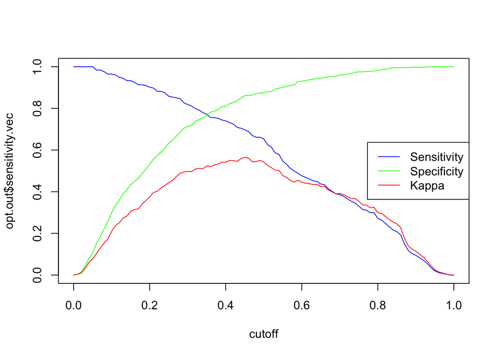

```r
step_kcv.out0 <- opt.cut.genn(step0_kcv, key.dummy(valid0))
opt.cut.plot(step_kcv.out0)
```

```r
#optimal by kappa score
step_kcv.out0$cutoff[which.max(step_kcv.out0$kappa.vec)]
```

```
## [1] 0.45
```

```r
#optimal by sensitivity/specificity balance
step_kcv.out0$cutoff[which.min(step_kcv.out0$ssdiff.vec)]
```

```
## [1] 0.35
```

Fit final model on combination of training and validation data

```r
set.seed(123)
# Fit K-fold CV model
bye2 <- capture.output(step0_kcv.final <- train(newgen ~ ., data = all.train0, family = "binomial",
                 method = "glmStepAIC", trControl = train_control, verbose = FALSE))
```

```r
step0_kcv.final <- step0_kcv.final$finalModel
summary(step0_kcv.final)
```

```
##
## Call:
## NULL
##
## Deviance Residuals:
##     Min       1Q   Median       3Q      Max
## -2.6507  -0.7237  -0.3739   0.7616   2.5465
##
## Coefficients:
##                   Estimate Std. Error z value Pr(>|z|)
## (Intercept)       0.479668   0.556656   0.862 0.388856
## popularity        0.073599   0.002681  27.455  < 2e-16 ***
## duration         -0.008863   0.001420  -6.240 4.37e-10 ***
## acousticness      1.215547   0.247876   4.904 9.40e-07 ***
## danceability      0.671646   0.452011   1.486 0.137304
## instrumentalness  2.806627   0.568219   4.939 7.84e-07 ***
## key1              0.502713   0.132119   3.805 0.000142 ***
## key2              0.445063   0.197936   2.249 0.024543 *
## key7              0.701810   0.161018   4.359 1.31e-05 ***
## loudness          0.244850   0.028416   8.617  < 2e-16 ***
## speechiness       2.206859   0.646922   3.411 0.000646 ***
## tempo            -0.002856   0.001705  -1.675 0.094010 .
## valence          -1.318599   0.239571  -5.504 3.71e-08 ***
## ---
## Signif. codes:  0 '***' 0.001 '**' 0.01 '*' 0.05 '.' 0.1 ' ' 1
##
## (Dispersion parameter for binomial family taken to be 1)
##
##     Null deviance: 5290.4  on 3971  degrees of freedom
## Residual deviance: 3778.3  on 3959  degrees of freedom
## AIC: 3804.3
##
## Number of Fisher Scoring iterations: 5
```

Stepwise 10kcv Logistic Model:

Compared to The full model, energy, key3 - key6, and key9 - key11 are not included in this model.

$$log(\frac{\hat \pi}{1 - \hat \pi}) = 0.480 + 0.074{Popularity} - 0.009{Duration} + 1.216{Acousticness}
\\ + 0.672{Danceability} + 2.807{Instrumentalness} + 0.503{Key1} + 0.445{Key2}
\\ + 0.702{Key7} + 0.245{Loudness} + 2.207{Speechiness} - 0.003{Tempo} - 1.319{Valence}$$
The audio features in this model that increase the odds of being categorized as a new generation kpop song multiplicativley are Popularity, Acousticness, Danceability, Instrumentalness, Loudness, Speechiness and choosing Key1(C#/D-flat minor), Key2(D minor), Key7(G minor) instead of Key0 (C minor). The features that decrease the odds multiplicatively of being categorized as a new generation kpop song are Duration, Tempo, and Valence.

Almost all the variables in the model: Popularity, Duration, Acousticness, Instrumentalness, Key1(C#/D-flat minor), Key2(D minor), Key7(G minor), Loudness, Speechiness, and Valence are significant predictors in contributing to the log of odds for categorizing a song into the newer generations of kpop versus the older generation. Only the predictors Tempo and Danceability are not significant.

```
#get predicted probabilities for training data
step_kcv.train0.pred <- step0_kcv$fitted.values
step_kcv.train0.y <- ifelse(step_kcv.train0.pred > 0.5, 1, 0) # using cutoff = 0.5
confusionMatrix(as.factor(step_kcv.train0.y), as.factor(train0$newgen),
                positive = "1")
```

Get prediction and performance evaluation for standard cut off 0.5

```r
#get predicted probabilities for the test data
step_kcv.test0.pred <- predict(step0_kcv.final, newdata = key.dummy(test0), type = "response")
step_kcv.test0.y <- ifelse(step_kcv.test0.pred > 0.5, 1, 0) # using cutoff = 0.5
confusionMatrix(as.factor(step_kcv.test0.y), as.factor(test0$newgen),
                positive = "1")
```

```
## Confusion Matrix and Statistics
##
##           Reference
## Prediction   0   1
##          0 365 105
##          1  63 168
##
##                Accuracy : 0.7603
##                  95% CI : (0.727, 0.7915)
##     No Information Rate : 0.6106
##     P-Value [Acc > NIR] : < 2e-16
##
##                   Kappa : 0.4816
##
##  Mcnemar's Test P-Value : 0.00156
##
##             Sensitivity : 0.6154
##             Specificity : 0.8528
##          Pos Pred Value : 0.7273
##          Neg Pred Value : 0.7766
##              Prevalence : 0.3894
##          Detection Rate : 0.2397
##    Detection Prevalence : 0.3295
##       Balanced Accuracy : 0.7341
##
##        'Positive' Class : 1
##
```

Get prediction and performance evaluation for optimal cut off 0.45 for highest kappa

```r
#get predicted probabilities for the test data
step_kcv.test0.pred <- predict(step0_kcv.final, newdata = key.dummy(test0), type = "response")
step_kcv.test0.y <- ifelse(step_kcv.test0.pred > 0.45, 1, 0) # using cutoff = 0.45
confusionMatrix(as.factor(step_kcv.test0.y), as.factor(test0$newgen),
                positive = "1")
```

```
## Confusion Matrix and Statistics
##
##           Reference
## Prediction   0   1
##          0 350  94
##          1  78 179
##
##                Accuracy : 0.7546
##                  95% CI : (0.721, 0.7861)
##     No Information Rate : 0.6106
##     P-Value [Acc > NIR] : 4.832e-16
##
##                   Kappa : 0.4785
##
##  Mcnemar's Test P-Value : 0.2527
##
##             Sensitivity : 0.6557
##             Specificity : 0.8178
##          Pos Pred Value : 0.6965
##          Neg Pred Value : 0.7883
##              Prevalence : 0.3894
##          Detection Rate : 0.2553
##    Detection Prevalence : 0.3666
##       Balanced Accuracy : 0.7367
##
##        'Positive' Class : 1
##
```

Get prediction and performance evaluation for optimal cut off 0.35 for best sensitivity/specificity balance

```r
#get predicted probabilities for the test data
step_kcv.test0.pred <- predict(step0_kcv.final, newdata = key.dummy(test0), type = "response")
step_kcv.test0.y <- ifelse(step_kcv.test0.pred > 0.35, 1, 0) # using cutoff = 0.35
confusionMatrix(as.factor(step_kcv.test0.y), as.factor(test0$newgen),
                positive = "1")
```

```
## Confusion Matrix and Statistics
##
##           Reference
## Prediction   0   1
##          0 308  75
##          1 120 198
##
##                Accuracy : 0.7218
##                  95% CI : (0.6871, 0.7547)
##     No Information Rate : 0.6106
##     P-Value [Acc > NIR] : 4.23e-10
##
##                   Kappa : 0.432
##
##  Mcnemar's Test P-Value : 0.001628
##
##             Sensitivity : 0.7253
##             Specificity : 0.7196
##          Pos Pred Value : 0.6226
##          Neg Pred Value : 0.8042
##              Prevalence : 0.3894
##          Detection Rate : 0.2825
##    Detection Prevalence : 0.4536
##       Balanced Accuracy : 0.7225
##
##        'Positive' Class : 1
##
```

### Variable Selection: All possible regression

```r
set.seed(123)
glmulti.out0 <- glmulti(newgen ~ ., data = train0,
                           level = 1,               # No interaction considered
            method = "h",            # Exhaustive approach
            crit = "aic",            # AIC as criteria
            confsetsize = 5,         # Keep 5 best models
            plotty = F, report = F,  # No plot or interim reports
            fitfunction = "glm",     # lm function
            family = binomial)       # binomial to run logistic regression
glmulti.out0@formulas
```

```
## [[1]]
## newgen ~ 1 + key + popularity + duration + acousticness + danceability +
##     instrumentalness + loudness + speechiness + valence
## <environment: 0x7ff77449fd08>
##
## [[2]]
## newgen ~ 1 + key + popularity + duration + acousticness + instrumentalness +
##     loudness + speechiness + tempo + valence
## <environment: 0x7ff77449fd08>
##
## [[3]]
## newgen ~ 1 + key + popularity + duration + acousticness + danceability +
##     instrumentalness + loudness + speechiness + tempo + valence
## <environment: 0x7ff77449fd08>
##
## [[4]]
## newgen ~ 1 + key + popularity + duration + acousticness + instrumentalness +
##     loudness + speechiness + valence
## <environment: 0x7ff77449fd08>
##
## [[5]]
## newgen ~ 1 + key + popularity + duration + acousticness + danceability +
##     energy + instrumentalness + loudness + speechiness + valence
## <environment: 0x7ff77449fd08>
```

view summary of top model

```r
summary(glmulti.out0@objects[[1]])
```

```
##
## Call:
## fitfunc(formula = as.formula(x), family = ..1, data = data)
##
## Deviance Residuals:
##     Min       1Q   Median       3Q      Max
## -2.5385  -0.7193  -0.3730   0.7703   2.4937
##
## Coefficients:
##                   Estimate Std. Error z value Pr(>|z|)
## (Intercept)       0.253030   0.554006   0.457   0.6479
## key1              0.183659   0.217029   0.846   0.3974
## key2              0.138257   0.271780   0.509   0.6110
## key3             -0.512165   0.321903  -1.591   0.1116
## key4             -0.269833   0.220893  -1.222   0.2219
## key5             -0.192689   0.209292  -0.921   0.3572
## key6             -0.132849   0.215687  -0.616   0.5379
## key7              0.545226   0.236436   2.306   0.0211 *
## key8             -0.183017   0.264006  -0.693   0.4882
## key9             -0.291443   0.227568  -1.281   0.2003
## key10            -0.279755   0.231273  -1.210   0.2264
## key11            -0.095537   0.203228  -0.470   0.6383
## popularity        0.073178   0.002942  24.872  < 2e-16 ***
## duration         -0.008930   0.001578  -5.661 1.50e-08 ***
## acousticness      1.266046   0.272732   4.642 3.45e-06 ***
## danceability      0.795588   0.476200   1.671   0.0948 .
## instrumentalness  2.741099   0.609355   4.498 6.85e-06 ***
## loudness          0.233697   0.031267   7.474 7.76e-14 ***
## speechiness       1.751742   0.699392   2.505   0.0123 *
## valence          -1.291818   0.263451  -4.903 9.42e-07 ***
## ---
## Signif. codes:  0 '***' 0.001 '**' 0.01 '*' 0.05 '.' 0.1 ' ' 1
##
## (Dispersion parameter for binomial family taken to be 1)
##
##     Null deviance: 4370.7  on 3270  degrees of freedom
## Residual deviance: 3131.9  on 3251  degrees of freedom
## AIC: 3171.9
##
## Number of Fisher Scoring iterations: 5
```

Store model

```r
allreg.logit0 <- glmulti.out0@objects[[1]]
```

find optimal cut off value

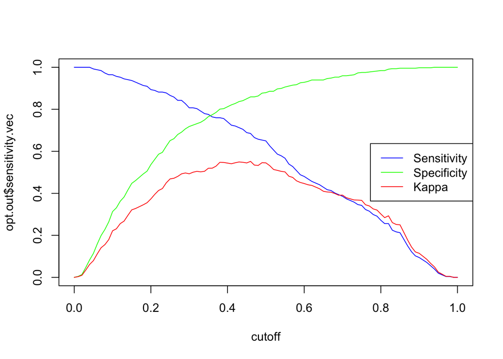

```r
allreg.out0 <- opt.cut.genn(allreg.logit0, valid0)
opt.cut.plot(allreg.out0)
```

```r
#optimal by kappa score
allreg.out0$cutoff[which.max(allreg.out0$kappa.vec)]
```

```
## [1] 0.46
```

```r
#optimal by sensitivity/specificity balance
allreg.out0$cutoff[which.min(allreg.out0$ssdiff.vec)]
```

```
## [1] 0.36
```

Fit final model on combo of train/validation data

```r
set.seed(123)
glmulti.out0.final <- glmulti(newgen ~ ., data = all.train0,
                           level = 1,               # No interaction considered
            method = "h",            # Exhaustive approach
            crit = "aic",            # AIC as criteria
            confsetsize = 5,         # Keep 5 best models
            plotty = F, report = F,  # No plot or interim reports
            fitfunction = "glm",     # lm function
            family = binomial)       # binomial to run logistic regression
glmulti.out0.final@formulas
```

```
## [[1]]
## newgen ~ 1 + key + popularity + duration + acousticness + danceability +
##     instrumentalness + loudness + speechiness + tempo + valence
## <environment: 0x7ff778ea0d88>
##
## [[2]]
## newgen ~ 1 + key + popularity + duration + acousticness + instrumentalness +
##     loudness + speechiness + tempo + valence
## <environment: 0x7ff778ea0d88>
##
## [[3]]
## newgen ~ 1 + key + popularity + duration + acousticness + danceability +
##     instrumentalness + loudness + speechiness + valence
## <environment: 0x7ff778ea0d88>
##
## [[4]]
## newgen ~ 1 + key + popularity + duration + acousticness + danceability +
##     energy + instrumentalness + loudness + speechiness + tempo +
##     valence
## <environment: 0x7ff778ea0d88>
##
## [[5]]
## newgen ~ 1 + key + popularity + duration + acousticness + energy +
##     instrumentalness + loudness + speechiness + tempo + valence
## <environment: 0x7ff778ea0d88>
```

```r
summary(glmulti.out0.final@objects[[1]])
```

```
##
## Call:
## fitfunc(formula = as.formula(x), family = ..1, data = data)
##
## Deviance Residuals:
##     Min       1Q   Median       3Q      Max
## -2.6540  -0.7136  -0.3748   0.7629   2.5168
##
## Coefficients:
##                   Estimate Std. Error z value Pr(>|z|)
## (Intercept)       0.684438   0.575289   1.190 0.234153
## key1              0.297959   0.198686   1.500 0.133705
## key2              0.240189   0.247124   0.972 0.331084
## key3             -0.545008   0.296357  -1.839 0.065911 .
## key4             -0.307534   0.203471  -1.511 0.130678
## key5             -0.255709   0.193235  -1.323 0.185735
## key6             -0.152897   0.198095  -0.772 0.440212
## key7              0.497174   0.218712   2.273 0.023015 *
## key8             -0.197091   0.239737  -0.822 0.411012
## key9             -0.270581   0.208453  -1.298 0.194272
## key10            -0.309520   0.211151  -1.466 0.142683
## key11            -0.076322   0.187929  -0.406 0.684655
## popularity        0.073773   0.002695  27.372  < 2e-16 ***
## duration         -0.008871   0.001424  -6.229 4.69e-10 ***
## acousticness      1.220727   0.248912   4.904 9.38e-07 ***
## danceability      0.694840   0.453367   1.533 0.125369
## instrumentalness  2.807384   0.568985   4.934 8.06e-07 ***
## loudness          0.245953   0.028509   8.627  < 2e-16 ***
## speechiness       2.213792   0.647156   3.421 0.000624 ***
## tempo            -0.002918   0.001709  -1.708 0.087679 .
## valence          -1.331118   0.240965  -5.524 3.31e-08 ***
## ---
## Signif. codes:  0 '***' 0.001 '**' 0.01 '*' 0.05 '.' 0.1 ' ' 1
##
## (Dispersion parameter for binomial family taken to be 1)
##
##     Null deviance: 5290.4  on 3971  degrees of freedom
## Residual deviance: 3771.4  on 3951  degrees of freedom
## AIC: 3813.4
##
## Number of Fisher Scoring iterations: 5
```

```r
allreg.logit0.final <- glmulti.out0.final@objects[[1]]
```

All Possible Regressions Model

Compared to the full model, Energy is not included in this model. Besides this difference, the full logit model and this one resulting from the all subsets method are very similar.

$$log(\frac{\hat \pi}{1 - \hat \pi}) = 0.684 + 0.074x_{Popularity} - 0.009x_{Duration} + 1.221x_{Acousticness}
\\ + 0.695_{Danceability} + 2.807x_{Instrumentalness} + 0.298x_{Key1} + 0.240x_{Key2}
\\ - 0.545x_{Key3} - 0.308x_{Key4} - 0.256x_{Key5} - 0.153x_{Key6} + 0.497x_{Key7}
\\ - 0.197x_{Key8} - 0.271x_{Key9} - 0.310x_{Key10} - 0.076x_{Key11} + 0.246x_{Loudness}
\\ + 2.214x_{Speechiness} - 0.003x_{Tempo} - 1.331x_{Valence}$$

The audio features in this model that increase the odds of being categorized as a new generation kpop song multiplicativley are Popularity, Acousticness, Danceability, Instrumentalness, Loudness, Speechiness and choosing Key1(C#/D-flat minor), Key2(D minor), Key7(G minor) instead of Key0 (C minor). The features that decrease the odds multiplicatively of being categorized as a new generation kpop song are Duration, Tempo, Valence and choosing Key3(D#/E-flat Minor), Key4(E minor), Key5(F Minor), Key6(F#/G-flat Minor), Key8 (G#/A-flat minor), Key9(A minor), Key10(A#/B-flat minor), Key11(B minor) instead of Key0(C).

Only the variables Popularity, Duration, Acousticness, Instrumentalness, Key7(G minor), Loudness, Speechiness, and Valence are significant predictors in contributing to the log of odds for categorizing a song into the newer generations of kpop versus the older generation.

try fitting training data to results from all possible regression variable selection

```
#get predicted probabilities for training data
all.train0.pred <- allreg.logit0$fitted.values
all.train0.y <- ifelse(all.train0.pred > 0.5, 1, 0) # using cutoff = 0.5
confusionMatrix(as.factor(all.train0.y), as.factor(train0$newgen),
                positive = "1")
```

```r
#get predicted probabilities for the test data
all.test0.pred <- predict(allreg.logit0.final, newdata = test0, type = "response")
all.test0.y <- ifelse(all.test0.pred > 0.5, 1, 0) # using cutoff = 0.5
confusionMatrix(as.factor(all.test0.y), as.factor(test0$newgen),
                positive = "1")
```

```
## Confusion Matrix and Statistics
##
##           Reference
## Prediction   0   1
##          0 364 105
##          1  64 168
##
##                Accuracy : 0.7589
##                  95% CI : (0.7255, 0.7901)
##     No Information Rate : 0.6106
##     P-Value [Acc > NIR] : < 2.2e-16
##
##                   Kappa : 0.4789
##
##  Mcnemar's Test P-Value : 0.002091
##
##             Sensitivity : 0.6154
##             Specificity : 0.8505
##          Pos Pred Value : 0.7241
##          Neg Pred Value : 0.7761
##              Prevalence : 0.3894
##          Detection Rate : 0.2397
##    Detection Prevalence : 0.3310
##       Balanced Accuracy : 0.7329
##
##        'Positive' Class : 1
##
```

Using the cutoff that yields the optimal kappa (0.46)

```r
#get predicted probabilities for the test data
all.test0.pred <- predict(allreg.logit0.final, newdata = test0, type = "response")
all.test0.y <- ifelse(all.test0.pred > 0.46, 1, 0) # using cutoff = 0.46
confusionMatrix(as.factor(all.test0.y), as.factor(test0$newgen),
                positive = "1")
```

```
## Confusion Matrix and Statistics
##
##           Reference
## Prediction   0   1
##          0 354  97
##          1  74 176
##
##                Accuracy : 0.7561
##                  95% CI : (0.7225, 0.7874)
##     No Information Rate : 0.6106
##     P-Value [Acc > NIR] : 2.439e-16
##
##                   Kappa : 0.4791
##
##  Mcnemar's Test P-Value : 0.09249
##
##             Sensitivity : 0.6447
##             Specificity : 0.8271
##          Pos Pred Value : 0.7040
##          Neg Pred Value : 0.7849
##              Prevalence : 0.3894
##          Detection Rate : 0.2511
##    Detection Prevalence : 0.3566
##       Balanced Accuracy : 0.7359
##
##        'Positive' Class : 1
##
```

Using the cutoff that yields the best balance between sensitivity/specificity (0.36)

```r
#get predicted probabilities for the test data
all.test0.pred <- predict(allreg.logit0.final, newdata = test0, type = "response")
all.test0.y <- ifelse(all.test0.pred > 0.36, 1, 0) # using cutoff = 0.36
confusionMatrix(as.factor(all.test0.y), as.factor(test0$newgen),
                positive = "1")
```

```
## Confusion Matrix and Statistics
##
##           Reference
## Prediction   0   1
##          0 314  79
##          1 114 194
##
##                Accuracy : 0.7247
##                  95% CI : (0.69, 0.7575)
##     No Information Rate : 0.6106
##     P-Value [Acc > NIR] : 1.496e-10
##
##                   Kappa : 0.4342
##
##  Mcnemar's Test P-Value : 0.01439
##
##             Sensitivity : 0.7106
##             Specificity : 0.7336
##          Pos Pred Value : 0.6299
##          Neg Pred Value : 0.7990
##              Prevalence : 0.3894
##          Detection Rate : 0.2767
##    Detection Prevalence : 0.4394
##       Balanced Accuracy : 0.7221
##
##        'Positive' Class : 1
##
```

### Regularized Regression: Ridge 10 fold Cross Validation

```r
set.seed(123)
ridge0 <- train(newgen ~ ., data = train0, method = "glmnet",
                      family = "binomial", trControl = train_control,
                      tuneGrid = expand.grid(alpha = 0,lambda = seq(0.001,0.1,by = 0.001)))
#best tuning parameter
ridge0$bestTune
```

```
##    alpha lambda
## 59     0  0.059
```

```r
ridge0.model <- coef(ridge0$finalModel, ridge0$bestTune$lambda)
ridge0.model
```

```
## 22 x 1 sparse Matrix of class "dgCMatrix"
##                             1
## (Intercept)       0.404201484
## popularity        0.050267951
## duration         -0.006688668
## acousticness      0.716299247
## danceability      0.053984531
## energy            0.141977513
## instrumentalness  1.290237295
## key1              0.174946153
## key2              0.142118253
## key3             -0.235400981
## key4             -0.156614643
## key5             -0.059769443
## key6             -0.007585153
## key7              0.418293009
## key8             -0.102490019
## key9             -0.146570340
## key10            -0.133898340
## key11            -0.037332328
## loudness          0.137276934
## speechiness       1.295583905
## tempo            -0.001508711
## valence          -0.796173118
```

Search for best cutoff using validation set

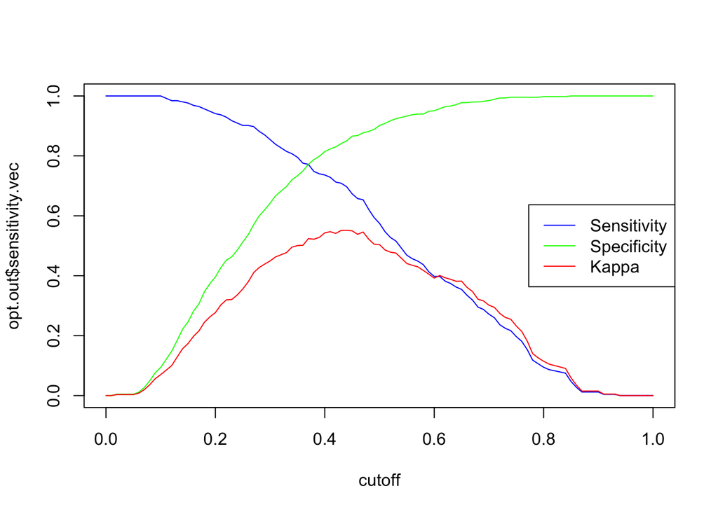

```r
ridge0.out <- reg.opt.cut.genn(ridge0, valid0)
opt.cut.plot(ridge0.out)
```

```r
# cut off by kappa
ridge0.out$cutoff[which.max(ridge0.out$kappa.vec)]
```

```
## [1] 0.44
```

```r
ridge0.out$cutoff[which.min(ridge0.out$ssdiff.vec)]
```

```
## [1] 0.37
```

create final model

```r
set.seed(123)
ridge0.final <- train(newgen ~ ., data = all.train0, method = "glmnet",
                      family = "binomial", trControl = train_control,
                      tuneGrid = expand.grid(alpha = 0,lambda = seq(0.001,0.1,by = 0.001)))
#best tuning parameter
ridge0.final$bestTune
```

```
##    alpha lambda
## 27     0  0.027
```

```r
ridge0.model.final <- coef(ridge0.final$finalModel, ridge0.final$bestTune$lambda)
ridge0.model.final
```

```
## 22 x 1 sparse Matrix of class "dgCMatrix"
##                             1
## (Intercept)       0.457113859
## popularity        0.059956306
## duration         -0.007571155
## acousticness      0.903667473
## danceability      0.281482597
## energy            0.159550705
## instrumentalness  1.839881313
## key1              0.288369103
## key2              0.236021753
## key3             -0.358247576
## key4             -0.201589608
## key5             -0.137298098
## key6             -0.047707837
## key7              0.445154135
## key8             -0.120450764
## key9             -0.177052649
## key10            -0.191406644
## key11            -0.030336323
## loudness          0.174909352
## speechiness       1.768983567
## tempo            -0.002333073
## valence          -1.020466344
```

Ridge 10 fold Cross Validation model
$$log(\frac{\hat \pi}{1 - \hat \pi}) = 0.457 + 0.060{Popularity} - 0.008{Duration} + 0.904{Acousticness} + 0.281{Danceability}
\\ + 0.160{Energy} + 1.840{Instrumentalness} + 0.288{Key1} + 0.236{Key2}
\\ - 0.358{Key3} - 0.202{Key4} - 0.137{Key5} - 0.048{Key6} + 0.445{Key7}
\\ - 0.120{Key8} - 0.177{Key9} - 0.191{Key10} - 0.030{Key11} + 0.175{Loudness}
\\ + 1.769{Speechiness} - 0.002{Tempo} - 1.020{Valence}$$

predict and evaluate on the test set where cutoff is at 0.5

```r
prob.ridge0 <- predict(ridge0.final, s = ridge0.final$bestTune, test0, type = "prob")
pred.ridge0 <- ifelse(prob.ridge0[,2] > 0.50, 1, 0) # using cutoff = 0.5
confusionMatrix(as.factor(pred.ridge0), as.factor(test0$newgen),
                positive = "1")
```

```
## Confusion Matrix and Statistics
##
##           Reference
## Prediction   0   1
##          0 368 110
##          1  60 163
##
##                Accuracy : 0.7575
##                  95% CI : (0.724, 0.7888)
##     No Information Rate : 0.6106
##     P-Value [Acc > NIR] : < 2.2e-16
##
##                   Kappa : 0.4726
##
##  Mcnemar's Test P-Value : 0.0001712
##
##             Sensitivity : 0.5971
##             Specificity : 0.8598
##          Pos Pred Value : 0.7309
##          Neg Pred Value : 0.7699
##              Prevalence : 0.3894
##          Detection Rate : 0.2325
##    Detection Prevalence : 0.3181
##       Balanced Accuracy : 0.7284
##
##        'Positive' Class : 1
##
```

predict and evaluate on the test set where cutoff is at 0.44 corresponding to optimal kappa

```r
prob.ridge0 <- predict(ridge0.final, s = ridge0.final$bestTune, test0, type = "prob")
pred.ridge0 <- ifelse(prob.ridge0[,2] > 0.44, 1, 0) # using cutoff = 0.44
confusionMatrix(as.factor(pred.ridge0), as.factor(test0$newgen),
                positive = "1")
```

```
## Confusion Matrix and Statistics
##
##           Reference
## Prediction   0   1
##          0 351  91
##          1  77 182
##
##                Accuracy : 0.7603
##                  95% CI : (0.727, 0.7915)
##     No Information Rate : 0.6106
##     P-Value [Acc > NIR] : <2e-16
##
##                   Kappa : 0.4913
##
##  Mcnemar's Test P-Value : 0.3159
##
##             Sensitivity : 0.6667
##             Specificity : 0.8201
##          Pos Pred Value : 0.7027
##          Neg Pred Value : 0.7941
##              Prevalence : 0.3894
##          Detection Rate : 0.2596
##    Detection Prevalence : 0.3695
##       Balanced Accuracy : 0.7434
##
##        'Positive' Class : 1
##
```

predict and evaluate on the test set where cutoff is at 0.37 corresponding to optimal balance of sensitivity and specificity

```r
prob.ridge0 <- predict(ridge0.final, s = ridge0.final$bestTune, test0, type = "prob")
pred.ridge0 <- ifelse(prob.ridge0[,2] > 0.37, 1, 0) # using cutoff = 0.37
confusionMatrix(as.factor(pred.ridge0), as.factor(test0$newgen),
                positive = "1")
```

```
## Confusion Matrix and Statistics
##
##           Reference
## Prediction   0   1
##          0 316  80
##          1 112 193
##
##                Accuracy : 0.7261
##                  95% CI : (0.6915, 0.7588)
##     No Information Rate : 0.6106
##     P-Value [Acc > NIR] : 8.807e-11
##
##                   Kappa : 0.436
##
##  Mcnemar's Test P-Value : 0.02527
##
##             Sensitivity : 0.7070
##             Specificity : 0.7383
##          Pos Pred Value : 0.6328
##          Neg Pred Value : 0.7980
##              Prevalence : 0.3894
##          Detection Rate : 0.2753
##    Detection Prevalence : 0.4351
##       Balanced Accuracy : 0.7226
##
##        'Positive' Class : 1
##
```

### Regularized Regression: Lasso 10 fold Cross Validation

```r
set.seed(123)
lasso0 <- train(newgen ~ ., data = train0, method = "glmnet",
                      family = "binomial", trControl = train_control,
                      tuneGrid = expand.grid(alpha = 1,lambda = seq(0.001,0.1,by = 0.001)))
# best parameter
lasso0$bestTune
```

```
##   alpha lambda
## 6     1  0.006
```

```r
# best coefficient
lasso0.model <- coef(lasso0$finalModel, lasso0$bestTune$lambda)
lasso0.model
```

```
## 22 x 1 sparse Matrix of class "dgCMatrix"
##                              1
## (Intercept)       0.1494922550
## popularity        0.0700602076
## duration         -0.0076454082
## acousticness      0.8090486021
## danceability      .
## energy            .
## instrumentalness  1.8799245602
## key1              0.2042606185
## key2              0.1025816495
## key3             -0.1392793472
## key4              .
## key5              .
## key6              .
## key7              0.5263940825
## key8              .
## key9             -0.0084177719
## key10            -0.0003869531
## key11             .
## loudness          0.1702199731
## speechiness       0.9470925199
## tempo            -0.0005875860
## valence          -0.8335715850
```

Search for best cutoff using validation set

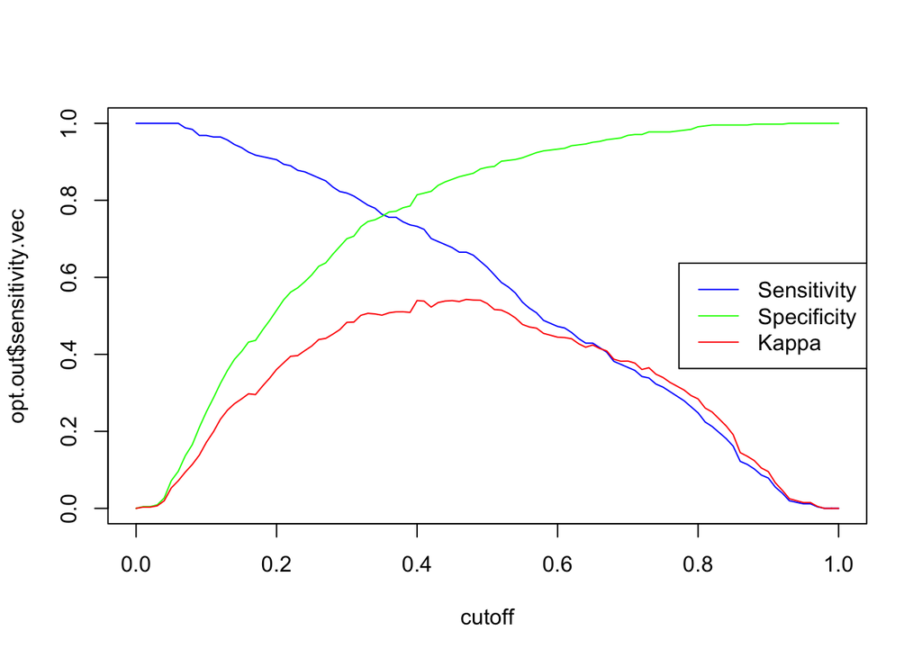

```r
lasso0.out <- reg.opt.cut.genn(lasso0, valid0)
opt.cut.plot(lasso0.out)
```

```r
# cut off by kappa
lasso0.out$cutoff[which.max(lasso0.out$kappa.vec)]
```

```
## [1] 0.47
```

```r
lasso0.out$cutoff[which.min(lasso0.out$ssdiff.vec)]
```

```
## [1] 0.35
```

create final model

```r
set.seed(123)
lasso0.final <- train(newgen ~ ., data = train0, method = "glmnet",
                      family = "binomial", trControl = train_control,
                      tuneGrid = expand.grid(alpha = 1,lambda = seq(0.001,0.1,by = 0.001)))
# best parameter
lasso0.final$bestTune
```

```
##   alpha lambda
## 6     1  0.006
```

```r
# best coefficient
lasso0.model.final <- coef(lasso0.final$finalModel, lasso0.final$bestTune$lambda)
lasso0.model.final
```

```
## 22 x 1 sparse Matrix of class "dgCMatrix"
##                              1
## (Intercept)       0.1494922550
## popularity        0.0700602076
## duration         -0.0076454082
## acousticness      0.8090486021
## danceability      .
## energy            .
## instrumentalness  1.8799245602
## key1              0.2042606185
## key2              0.1025816495
## key3             -0.1392793472
## key4              .
## key5              .
## key6              .
## key7              0.5263940825
## key8              .
## key9             -0.0084177719
## key10            -0.0003869531
## key11             .
## loudness          0.1702199731
## speechiness       0.9470925199
## tempo            -0.0005875860
## valence          -0.8335715850
```

Lasso 10 fold Cross Validation model:

Compared to the full model, this one leaves out the variables of danceability, energy, Key4 - Key6, Key 8, and Key 11

$$log(\frac{\hat \pi}{1 - \hat \pi}) = 0.149 + 0.070{Popularity} - 0.008{Duration} + 0.809{Acousticness} + 1.880{Instrumentalness}
\\
+ 0.204{Key1} + 0.103{Key2} - 0.139{Key3} + 0.526{Key7} - 0.008{Key9} - 0.0004{Key10}
\\
+ 0.170{Loudness} + 0.947{Speechiness} - 0.001{Tempo} - 0.834{Valence}$$

predict and evaluate on the test set where cutoff is at 0.5

```r
prob.lasso0 <- predict(lasso0.final, s = lasso0.final$bestTune, test0, type = "prob")
pred.lasso0 <- ifelse(prob.lasso0[,2] > 0.50, 1, 0) # using cutoff = 0.5
confusionMatrix(as.factor(pred.lasso0), as.factor(test0$newgen),
                positive = "1")
```

```
## Confusion Matrix and Statistics
##
##           Reference
## Prediction   0   1
##          0 369 107
##          1  59 166
##
##                Accuracy : 0.7632
##                  95% CI : (0.7299, 0.7942)
##     No Information Rate : 0.6106
##     P-Value [Acc > NIR] : < 2.2e-16
##
##                   Kappa : 0.4857
##
##  Mcnemar's Test P-Value : 0.0002644
##
##             Sensitivity : 0.6081
##             Specificity : 0.8621
##          Pos Pred Value : 0.7378
##          Neg Pred Value : 0.7752
##              Prevalence : 0.3894
##          Detection Rate : 0.2368
##    Detection Prevalence : 0.3210
##       Balanced Accuracy : 0.7351
##
##        'Positive' Class : 1
##
```

predict and evaluate on the test set where cutoff is at 0.47 corresponding to optimal kappa

```r
prob.lasso0 <- predict(lasso0.final, s = lasso0.final$bestTune, test0, type = "prob")
pred.lasso0 <- ifelse(prob.lasso0[,2] > 0.47, 1, 0) # using cutoff = 0.47
confusionMatrix(as.factor(pred.lasso0), as.factor(test0$newgen),
                positive = "1")
```

```
## Confusion Matrix and Statistics
##
##           Reference
## Prediction   0   1
##          0 361  96
##          1  67 177
##
##                Accuracy : 0.7675
##                  95% CI : (0.7344, 0.7983)
##     No Information Rate : 0.6106
##     P-Value [Acc > NIR] : <2e-16
##
##                   Kappa : 0.5015
##
##  Mcnemar's Test P-Value : 0.0283
##
##             Sensitivity : 0.6484
##             Specificity : 0.8435
##          Pos Pred Value : 0.7254
##          Neg Pred Value : 0.7899
##              Prevalence : 0.3894
##          Detection Rate : 0.2525
##    Detection Prevalence : 0.3481
##       Balanced Accuracy : 0.7459
##
##        'Positive' Class : 1
##
```

predict and evaluate on the test set where cutoff is at 0.35 corresponding to optimal balance of sensitivity and specificity

```r
prob.lasso0 <- predict(lasso0.final, s = lasso0.final$bestTune, test0, type = "prob")
pred.lasso0 <- ifelse(prob.lasso0[,2] > 0.35, 1, 0) # using cutoff = 0.35
confusionMatrix(as.factor(pred.lasso0), as.factor(test0$newgen),
                positive = "1")
```

```
## Confusion Matrix and Statistics
##
##           Reference
## Prediction   0   1
##          0 315  72
##          1 113 201
##
##                Accuracy : 0.7361
##                  95% CI : (0.7018, 0.7684)
##     No Information Rate : 0.6106
##     P-Value [Acc > NIR] : 1.767e-12
##
##                   Kappa : 0.4597
##
##  Mcnemar's Test P-Value : 0.003273
##
##             Sensitivity : 0.7363
##             Specificity : 0.7360
##          Pos Pred Value : 0.6401
##          Neg Pred Value : 0.8140
##              Prevalence : 0.3894
##          Detection Rate : 0.2867
##    Detection Prevalence : 0.4479
##       Balanced Accuracy : 0.7361
##
##        'Positive' Class : 1
##
```

### Regularized Regression: Elastic Net 10 fold Cross Validation

```r
set.seed(123)
enet0 <- train(newgen ~ ., data = train0, method = "glmnet",
                      family = "binomial", trControl = train_control,
                      tuneGrid = expand.grid(alpha = seq(0,1,by = 0.05),lambda = seq(0.001,0.1,by = 0.001)))
# best parameter
enet0$bestTune
```

```
##      alpha lambda
## 1807   0.9  0.007
```

```r
# best coefficient
enet0.model <- coef(enet0$finalModel, enet0$bestTune$lambda)
enet0.model
```

```
## 22 x 1 sparse Matrix of class "dgCMatrix"
##                              1
## (Intercept)       0.1144160676
## popularity        0.0695050297
## duration         -0.0075411443
## acousticness      0.7851186066
## danceability      .
## energy            .
## instrumentalness  1.8167573324
## key1              0.1963679942
## key2              0.0924761690
## key3             -0.1274884652
## key4              .
## key5              .
## key6              .
## key7              0.5145230452
## key8              .
## key9             -0.0030985668
## key10            -0.0002123031
## key11             .
## loudness          0.1662660576
## speechiness       0.9089104851
## tempo            -0.0004849719
## valence          -0.8170659432
```

search for best cutoff with validation set

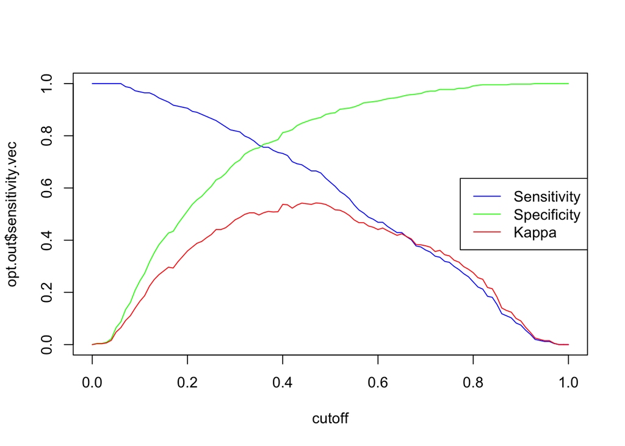

```r
enet0.out <- reg.opt.cut.genn(enet0, valid0)
opt.cut.plot(enet0.out)
```

```r
# cut off by kappa
enet0.out$cutoff[which.max(enet0.out$kappa.vec)]
```

```
## [1] 0.47
```

```r
enet0.out$cutoff[which.min(enet0.out$ssdiff.vec)]
```

```
## [1] 0.35
```

create final model on train and validation

```r
set.seed(123)
enet0.final <- train(newgen ~ ., data = all.train0, method = "glmnet",
                      family = "binomial", trControl = train_control,
                      tuneGrid = expand.grid(alpha = seq(0,1,by = 0.05),lambda = seq(0.001,0.1,by = 0.001)))
# best parameter
enet0.final$bestTune
```

```
##      alpha lambda
## 2007     1  0.007
```

```r
# best coefficient
enet0.model.final <- coef(enet0.final$finalModel, enet0.final$bestTune$lambda)
enet0.model.final
```

```
## 22 x 1 sparse Matrix of class "dgCMatrix"
##                              1
## (Intercept)       0.1163904797
## popularity        0.0700244223
## duration         -0.0073024011
## acousticness      0.7370603058
## danceability      .
## energy            .
## instrumentalness  1.7709183066
## key1              0.3047324210
## key2              0.1742593151
## key3             -0.1287016323
## key4              .
## key5              .
## key6              .
## key7              0.4538612677
## key8              .
## key9              .
## key10            -0.0003978668
## key11             .
## loudness          0.1699000285
## speechiness       1.1537975343
## tempo            -0.0009802803
## valence          -0.8471840404
```

Elastic Net 10 fold Cross Validation model:

Compared to the full model, this one leaves out the variables of danceability, energy, Key4 - Key6, Key8, Key9, and Key11

$$log(\frac{\hat \pi}{1 - \hat \pi}) = 0.116 + 0.070{Popularity} - 0.008{Duration} + 0.737{Acousticness} + 1.771{Instrumentalness}
\\
+ 0.305{Key1} + 0.174{Key2} - 0.129{Key3} + 0.454{Key7} - 0.0004{Key10}
\\
+ 0.170{Loudness} + 1.154{Speechiness} - 0.001{Tempo} -0.847{Valence}$$

predict and evaluate on the test set where cutoff is at 0.5

```r
prob.enet0 <- predict(enet0.final, s = enet0.final$bestTune, test0, type = "prob")
pred.enet0 <- ifelse(prob.enet0[,2] > 0.50, 1, 0) # using cutoff = 0.5
confusionMatrix(as.factor(pred.enet0), as.factor(test0$newgen),
                positive = "1")
```

```
## Confusion Matrix and Statistics
##
##           Reference
## Prediction   0   1
##          0 367 105
##          1  61 168
##
##                Accuracy : 0.7632
##                  95% CI : (0.7299, 0.7942)
##     No Information Rate : 0.6106
##     P-Value [Acc > NIR] : < 2.2e-16
##
##                   Kappa : 0.4871
##
##  Mcnemar's Test P-Value : 0.0008455
##
##             Sensitivity : 0.6154
##             Specificity : 0.8575
##          Pos Pred Value : 0.7336
##          Neg Pred Value : 0.7775
##              Prevalence : 0.3894
##          Detection Rate : 0.2397
##    Detection Prevalence : 0.3267
##       Balanced Accuracy : 0.7364
##
##        'Positive' Class : 1
##
```

predict and evaluate on the test set where cutoff is at 0.47 corresponding to optimal kappa

```r
prob.enet0 <- predict(enet0.final, s = enet0.final$bestTune, test0, type = "prob")
pred.enet0 <- ifelse(prob.enet0[,2] > 0.47, 1, 0) # using cutoff = 0.47
confusionMatrix(as.factor(pred.enet0), as.factor(test0$newgen),
                positive = "1")
```

```
## Confusion Matrix and Statistics
##
##           Reference
## Prediction   0   1
##          0 359  97
##          1  69 176
##
##                Accuracy : 0.7632
##                  95% CI : (0.7299, 0.7942)
##     No Information Rate : 0.6106
##     P-Value [Acc > NIR] : < 2e-16
##
##                   Kappa : 0.4926
##
##  Mcnemar's Test P-Value : 0.03612
##
##             Sensitivity : 0.6447
##             Specificity : 0.8388
##          Pos Pred Value : 0.7184
##          Neg Pred Value : 0.7873
##              Prevalence : 0.3894
##          Detection Rate : 0.2511
##    Detection Prevalence : 0.3495
##       Balanced Accuracy : 0.7417
##
##        'Positive' Class : 1
##
```

predict and evaluate on the test set where cutoff is at 0.35 corresponding to optimal balance of sensitivity and specificity

```r
prob.enet0 <- predict(enet0.final, s = enet0.final$bestTune, test0, type = "prob")
pred.enet0 <- ifelse(prob.enet0[,2] > 0.35, 1, 0) # using cutoff = 0.35
confusionMatrix(as.factor(pred.enet0), as.factor(test0$newgen),
                positive = "1")
```

```
## Confusion Matrix and Statistics
##
##           Reference
## Prediction   0   1
##          0 317  73
##          1 111 200
##
##                Accuracy : 0.7375
##                  95% CI : (0.7033, 0.7697)
##     No Information Rate : 0.6106
##     P-Value [Acc > NIR] : 9.825e-13
##
##                   Kappa : 0.4616
##
##  Mcnemar's Test P-Value : 0.006378
##
##             Sensitivity : 0.7326
##             Specificity : 0.7407
##          Pos Pred Value : 0.6431
##          Neg Pred Value : 0.8128
##              Prevalence : 0.3894
##          Detection Rate : 0.2853
##    Detection Prevalence : 0.4437
##       Balanced Accuracy : 0.7366
##
##        'Positive' Class : 1
##
```

### Deciding on the best model for Mode 0 songs

Performance metrics

```r
mode0.results <- data.frame(Model = c("Full", "Step", "Step 10CV", "AllReg", "Ridge 10CV", "Lasso 10CV", "ElasticNet 10CV"),
                            cutoff = c(0.35, 0.36, 0.35, 0.36, 0.37, 0.35, 0.35), #optimal balance between sensitivity and specificity
                            #AIC = c(3815.2, 3813.4, 3804.3, 3813.4, NA, NA, NA),
                            Accuracy = c(0.7175, 0.7247, 0.7218, 0.7247, 0.7261, 0.7361, 0.7375),
                            Kappa = c(0.4222, 0.4342, 0.4320, 0.4342, 0.4360, 0.4597, 0.4616),
                            Sensitivity = c(0.7143, 0.7106, 0.7253, 0.7106, 0.7070, 0.7363, 0.7326),
                            Specificity = c(0.7196, 0.7336, 0.7196, 0.7336, 0.7383, 0.7360, 0.7407))
mode0.results
```

```
##             Model cutoff Accuracy  Kappa Sensitivity Specificity
## 1            Full   0.35   0.7175 0.4222      0.7143      0.7196
## 2            Step   0.36   0.7247 0.4342      0.7106      0.7336
## 3       Step 10CV   0.35   0.7218 0.4320      0.7253      0.7196
## 4          AllReg   0.36   0.7247 0.4342      0.7106      0.7336
## 5      Ridge 10CV   0.37   0.7261 0.4360      0.7070      0.7383
## 6      Lasso 10CV   0.35   0.7361 0.4597      0.7363      0.7360
## 7 ElasticNet 10CV   0.35   0.7375 0.4616      0.7326      0.7407
```

All models have VERY similar results. Therefore, one could argue that each would work as equally as well as one another. Based on the analysis done with this sample, the best model would be the Elastic Net model, as it has the highest accuracy score, as well as the sensitivity and specifity scores simultaneously having fairly high rates.

Elastic Net 10 fold Cross Validation model:

Compared to the full model, this one leaves out the variables of danceability, energy, Key4 - Key6, Key8, Key9, and Key11

$$log(\frac{\hat \pi}{1 - \hat \pi}) = 0.116 + 0.070{Popularity} - 0.008{Duration} + 0.737{Acousticness} + 1.771{Instrumentalness}
\\
+ 0.305{Key1} + 0.174{Key2} - 0.129{Key3} + 0.454{Key7} - 0.0004{Key10}
\\
+ 0.170{Loudness} + 1.154{Speechiness} - 0.001{Tempo} -0.847{Valence}$$

## Logistic Where mode = 1

Major key

Full logistic regression model

```r
set.seed(123)
logit1 <- glm(newgen ~., data = train1, family = "binomial")
summary(logit1)
```

```
##
## Call:
## glm(formula = newgen ~ ., family = "binomial", data = train1)
##
## Deviance Residuals:
##     Min       1Q   Median       3Q      Max
## -2.8430  -0.7103  -0.3904   0.7627   2.9471
##
## Coefficients:
##                    Estimate Std. Error z value Pr(>|z|)
## (Intercept)      -0.6681947  0.6340974  -1.054 0.291987
## popularity        0.0802393  0.0025478  31.494  < 2e-16 ***
## duration         -0.0080679  0.0012109  -6.663 2.69e-11 ***
## acousticness      0.8368094  0.2166599   3.862 0.000112 ***
## danceability      0.5891706  0.3723907   1.582 0.113620
## energy            0.3755475  0.4314675   0.870 0.384084
## instrumentalness  2.3802489  0.4666578   5.101 3.39e-07 ***
## key1             -0.4907517  0.1357268  -3.616 0.000300 ***
## key2             -0.0819545  0.1410943  -0.581 0.561342
## key3              0.1227852  0.2247053   0.546 0.584772
## key4              0.1179265  0.1825478   0.646 0.518277
## key5             -0.2654668  0.1626960  -1.632 0.102748
## key6             -0.3543308  0.1613573  -2.196 0.028096 *
## key7             -0.2060473  0.1315679  -1.566 0.117327
## key8             -0.2526750  0.1518444  -1.664 0.096105 .
## key9              0.0594385  0.1642315   0.362 0.717413
## key10            -0.1398960  0.1958849  -0.714 0.475119
## key11            -0.2308010  0.1686715  -1.368 0.171204
## loudness          0.1538764  0.0299183   5.143 2.70e-07 ***
## speechiness       0.5854851  0.6330100   0.925 0.355006
## tempo             0.0002345  0.0013845   0.169 0.865507
## valence          -0.7342801  0.2238020  -3.281 0.001035 **
## ---
## Signif. codes:  0 '***' 0.001 '**' 0.01 '*' 0.05 '.' 0.1 ' ' 1
##
## (Dispersion parameter for binomial family taken to be 1)
##
##     Null deviance: 6738.9  on 5136  degrees of freedom
## Residual deviance: 4853.1  on 5115  degrees of freedom
## AIC: 4897.1
##
## Number of Fisher Scoring iterations: 5
```

confusion matrix on the training data:

```
logit.train1.pred <- logit1$fitted.values
logit.train1.y <- ifelse(logit.train1.pred > 0.5, 1, 0) # using cutoff = 0.5
confusionMatrix(as.factor(logit.train1.y), as.factor(train1$newgen),
                positive = "1")
```

find optimal cut off value

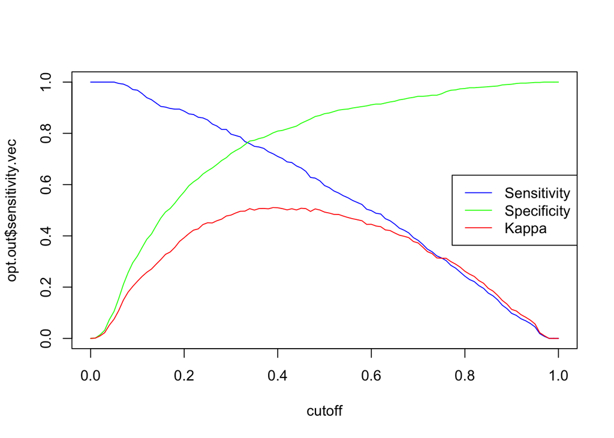

```r
logit.out1 <- opt.cut.genn(logit1, valid1)
opt.cut.plot(logit.out1)
```

```r
#optimal by kappa score
logit.out1$cutoff[which.max(logit.out1$kappa.vec)]
```

```
## [1] 0.39
```

```r
#optimal by sensitivity/specificity balance
logit.out1$cutoff[which.min(logit.out1$ssdiff.vec)]
```

```
## [1] 0.34
```

Final full logistic model fit to the combo of train and validation data.

```r
set.seed(123)
logit1.final <- glm(newgen ~., data = all.train1, family = "binomial")
summary(logit1.final)
```

```
##
## Call:
## glm(formula = newgen ~ ., family = "binomial", data = all.train1)
##
## Deviance Residuals:
##     Min       1Q   Median       3Q      Max
## -2.8344  -0.7123  -0.3927   0.7651   2.9689
##
## Coefficients:
##                    Estimate Std. Error z value Pr(>|z|)
## (Intercept)      -0.7830317  0.5708490  -1.372 0.170158
## popularity        0.0789437  0.0022892  34.485  < 2e-16 ***
## duration         -0.0085365  0.0010848  -7.869 3.57e-15 ***
## acousticness      0.8822530  0.1961078   4.499 6.83e-06 ***
## danceability      0.6653079  0.3371238   1.973 0.048441 *
## energy            0.5365435  0.3878817   1.383 0.166583
## instrumentalness  2.4711501  0.3976516   6.214 5.15e-10 ***
## key1             -0.4146176  0.1235416  -3.356 0.000791 ***
## key2              0.0018795  0.1277455   0.015 0.988261
## key3              0.1485926  0.2005722   0.741 0.458789
## key4              0.2800836  0.1627272   1.721 0.085217 .
## key5             -0.2173409  0.1487580  -1.461 0.144005
## key6             -0.2796935  0.1473201  -1.899 0.057625 .
## key7             -0.1606723  0.1198348  -1.341 0.179991
## key8             -0.1850034  0.1368249  -1.352 0.176338
## key9              0.0055223  0.1489946   0.037 0.970434
## key10            -0.0713479  0.1781632  -0.400 0.688815
## key11            -0.0935255  0.1537171  -0.608 0.542905
## loudness          0.1537432  0.0268960   5.716 1.09e-08 ***
## speechiness       0.7920192  0.5616476   1.410 0.158489
## tempo             0.0001812  0.0012661   0.143 0.886173
## valence          -0.7418336  0.2024359  -3.665 0.000248 ***
## ---
## Signif. codes:  0 '***' 0.001 '**' 0.01 '*' 0.05 '.' 0.1 ' ' 1
##
## (Dispersion parameter for binomial family taken to be 1)
##
##     Null deviance: 8158.1  on 6237  degrees of freedom
## Residual deviance: 5892.1  on 6216  degrees of freedom
## AIC: 5936.1
##
## Number of Fisher Scoring iterations: 5
```

Full Logistic model

$$log(\frac{\hat \pi}{1 - \hat \pi}) = -0.783 + 0.079{Popularity} - 0.009{Duration} + 0.882{Acousticness} + 0.665{Danceability}
\\ + 0.537{Energy} + 2.471{Instrumentalness} - 0.415{Key1} + 0.002{Key2}
\\ + 0.149{Key3} + 0.280{Key4} - 0.217{Key5} - 0.280{Key6} - 0.161{Key7}
\\ - 0.185{Key8} + 0.006{Key9} - 0.071{Key10} - 0.094{Key11} + 0.154{Loudness}
\\ + 0.792{Speechiness} + 0.0002{Tempo} - 0.742{Valence}$$

The audio features in this model that increase the odds of being categorized as a new generation kpop song multiplicativley are Popularity, Acousticness, Danceability, Energy, Instrumentalness, Loudness, Speechiness, Tempo and choosing Key2(D major), Key3(D#/E-flat Major), Key4(E Major), Key9(A Major), instead of Key0 (C Major). The features that decrease the odds multiplicatively of being categorized as a new generation kpop song are Duration, Valence and choosing, Key5(F Major), Key6(F#/G-flat Major), Key8 (G#/A-flat Major), Key10(A#/B-flat Major), Key11(B Major) instead of Key0(C Major).

confusion matrix on the test data using standard cut off

```r
#get predicted probabilities for the test data
logit.test1.pred <- predict(logit1.final, newdata = test1, type = "response")
logit.test1.y <- ifelse(logit.test1.pred > 0.5, 1, 0) # using cutoff = 0.5
confusionMatrix(as.factor(logit.test1.y), as.factor(test1$newgen),
                positive = "1")
```

```
## Confusion Matrix and Statistics
##
##           Reference
## Prediction   0   1
##          0 592 162
##          1  98 249
##
##                Accuracy : 0.7639
##                  95% CI : (0.7376, 0.7887)
##     No Information Rate : 0.6267
##     P-Value [Acc > NIR] : < 2.2e-16
##
##                   Kappa : 0.4789
##
##  Mcnemar's Test P-Value : 9.341e-05
##
##             Sensitivity : 0.6058
##             Specificity : 0.8580
##          Pos Pred Value : 0.7176
##          Neg Pred Value : 0.7851
##              Prevalence : 0.3733
##          Detection Rate : 0.2262
##    Detection Prevalence : 0.3152
##       Balanced Accuracy : 0.7319
##
##        'Positive' Class : 1
##
```

confusion matrix on the test data using optimal cutoff based on kappa (0.39)

```r
#get predicted probabilities for the test data
logit.test1.pred <- predict(logit1.final, newdata = test1, type = "response")
logit.test1.y <- ifelse(logit.test1.pred > 0.39, 1, 0) # using cutoff = 0.39
confusionMatrix(as.factor(logit.test1.y), as.factor(test1$newgen),
                positive = "1")
```

```
## Confusion Matrix and Statistics
##
##           Reference
## Prediction   0   1
##          0 547 118
##          1 143 293
##
##                Accuracy : 0.7629
##                  95% CI : (0.7367, 0.7878)
##     No Information Rate : 0.6267
##     P-Value [Acc > NIR] : <2e-16
##
##                   Kappa : 0.4995
##
##  Mcnemar's Test P-Value : 0.1374
##
##             Sensitivity : 0.7129
##             Specificity : 0.7928
##          Pos Pred Value : 0.6720
##          Neg Pred Value : 0.8226
##              Prevalence : 0.3733
##          Detection Rate : 0.2661
##    Detection Prevalence : 0.3960
##       Balanced Accuracy : 0.7528
##
##        'Positive' Class : 1
##
```

confusion matrix on the test data using optimal cutoff based on sensitivity/specificty balance (0.34)

```r
#get predicted probabilities for the test data
logit.test1.pred <- predict(logit1.final, newdata = test1, type = "response")
logit.test1.y <- ifelse(logit.test1.pred > 0.34, 1, 0) # using cutoff = 0.34
confusionMatrix(as.factor(logit.test1.y), as.factor(test1$newgen),
                positive = "1")
```

```
## Confusion Matrix and Statistics
##
##           Reference
## Prediction   0   1
##          0 518  95
##          1 172 316
##
##                Accuracy : 0.7575
##                  95% CI : (0.7311, 0.7825)
##     No Information Rate : 0.6267
##     P-Value [Acc > NIR] : < 2.2e-16
##
##                   Kappa : 0.5006
##
##  Mcnemar's Test P-Value : 3.301e-06
##
##             Sensitivity : 0.7689
##             Specificity : 0.7507
##          Pos Pred Value : 0.6475
##          Neg Pred Value : 0.8450
##              Prevalence : 0.3733
##          Detection Rate : 0.2870
##    Detection Prevalence : 0.4432
##       Balanced Accuracy : 0.7598
##
##        'Positive' Class : 1
##
```

### Variable Selection: Stepwise

stepwise

```r
set.seed(123)
logit1.none <- glm(newgen ~ 1, data = train1, family = binomial)
step1 <- step(logit1.none,
                 list(lower=formula(logit1.none), upper = formula(logit1)),
                 direction = "both",
                 trace=0)
formula(step1)
```

```
## newgen ~ popularity + duration + loudness + acousticness + instrumentalness +
##     valence + key + danceability
```

```r
summary(step1)
```

```
##
## Call:
## glm(formula = newgen ~ popularity + duration + loudness + acousticness +
##     instrumentalness + valence + key + danceability, family = binomial,
##     data = train1)
##
## Deviance Residuals:
##     Min       1Q   Median       3Q      Max
## -2.8603  -0.7101  -0.3891   0.7640   2.9625
##
## Coefficients:
##                   Estimate Std. Error z value Pr(>|z|)
## (Intercept)      -0.174528   0.403868  -0.432 0.665639
## popularity        0.080283   0.002512  31.958  < 2e-16 ***
## duration         -0.008310   0.001199  -6.931 4.17e-12 ***
## loudness          0.169250   0.022608   7.486 7.09e-14 ***
## acousticness      0.705422   0.181524   3.886 0.000102 ***
## instrumentalness  2.369217   0.466017   5.084 3.70e-07 ***
## valence          -0.645666   0.212511  -3.038 0.002379 **
## key1             -0.488374   0.135582  -3.602 0.000316 ***
## key2             -0.077569   0.140970  -0.550 0.582149
## key3              0.118963   0.224447   0.530 0.596093
## key4              0.112844   0.182502   0.618 0.536367
## key5             -0.271520   0.162560  -1.670 0.094865 .
## key6             -0.346110   0.161120  -2.148 0.031702 *
## key7             -0.200362   0.131369  -1.525 0.127213
## key8             -0.251743   0.151740  -1.659 0.097108 .
## key9              0.055155   0.164077   0.336 0.736754
## key10            -0.143506   0.195935  -0.732 0.463914
## key11            -0.235120   0.168610  -1.394 0.163179
## danceability      0.526138   0.356026   1.478 0.139459
## ---
## Signif. codes:  0 '***' 0.001 '**' 0.01 '*' 0.05 '.' 0.1 ' ' 1
##
## (Dispersion parameter for binomial family taken to be 1)
##
##     Null deviance: 6738.9  on 5136  degrees of freedom
## Residual deviance: 4855.2  on 5118  degrees of freedom
## AIC: 4893.2
##
## Number of Fisher Scoring iterations: 5
```

confusion matrix on the training data:

```
step.train1.pred <- step1$fitted.values
step.train1.y <- ifelse(step.train1.pred > 0.5, 1, 0) # using cutoff = 0.5
confusionMatrix(as.factor(step.train1.y), as.factor(train1$newgen),
                positive = "1")
```

find optimal cut off value

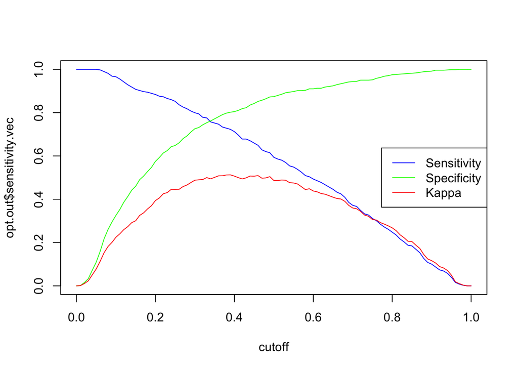

```r
step.out1 <- opt.cut.genn(step1, valid1)
opt.cut.plot(step.out1)
```

```r
#optimal by kappa score
step.out1$cutoff[which.max(step.out1$kappa.vec)]
```

```
## [1] 0.39
```

```r
#optimal by sensitivity/specificity balance
step.out1$cutoff[which.min(step.out1$ssdiff.vec)]
```

```
## [1] 0.34
```

final stepwise model

```r
set.seed(123)
logit1.none <- glm(newgen ~ 1, data = all.train1, family = binomial)
step1.final <- step(logit1.none,
                 list(lower=formula(logit1.none), upper = formula(logit1)),
                 direction = "both",
                 trace=0)
formula(step1.final)
```

```
## newgen ~ popularity + duration + loudness + instrumentalness +
##     acousticness + valence + key + danceability + speechiness
```

```r
summary(step1.final)
```

```
##
## Call:
## glm(formula = newgen ~ popularity + duration + loudness + instrumentalness +
##     acousticness + valence + key + danceability + speechiness,
##     family = binomial, data = all.train1)
##
## Deviance Residuals:
##     Min       1Q   Median       3Q      Max
## -2.8350  -0.7108  -0.3916   0.7636   2.9929
##
## Coefficients:
##                   Estimate Std. Error z value Pr(>|z|)
## (Intercept)      -0.225784   0.367178  -0.615 0.538610
## popularity        0.078529   0.002266  34.650  < 2e-16 ***
## duration         -0.008588   0.001085  -7.913 2.52e-15 ***
## loudness          0.178352   0.020395   8.745  < 2e-16 ***
## instrumentalness  2.516403   0.396780   6.342 2.27e-10 ***
## acousticness      0.739469   0.166784   4.434 9.26e-06 ***
## valence          -0.667741   0.194510  -3.433 0.000597 ***
## key1             -0.415093   0.123488  -3.361 0.000775 ***
## key2              0.001643   0.127686   0.013 0.989736
## key3              0.146881   0.200396   0.733 0.463586
## key4              0.279109   0.162751   1.715 0.086356 .
## key5             -0.222002   0.148690  -1.493 0.135425
## key6             -0.276443   0.147164  -1.878 0.060317 .
## key7             -0.162392   0.119805  -1.355 0.175269
## key8             -0.187019   0.136815  -1.367 0.171640
## key9              0.002166   0.148954   0.015 0.988400
## key10            -0.071686   0.178289  -0.402 0.687626
## key11            -0.094143   0.153573  -0.613 0.539865
## danceability      0.632472   0.322859   1.959 0.050116 .
## speechiness       0.980171   0.541930   1.809 0.070503 .
## ---
## Signif. codes:  0 '***' 0.001 '**' 0.01 '*' 0.05 '.' 0.1 ' ' 1
##
## (Dispersion parameter for binomial family taken to be 1)
##
##     Null deviance: 8158.1  on 6237  degrees of freedom
## Residual deviance: 5894.0  on 6218  degrees of freedom
## AIC: 5934
##
## Number of Fisher Scoring iterations: 5
```

Stepwise Logistic Model:

Compared to the full model, the stepwise logistic model does not have Tempo or Energy in the model

$$log(\frac{\hat \pi}{1 - \hat \pi}) = -0.226 + 0.079{Popularity} - 0.009Duration + 0.739{Acousticness} + 0.632{Danceability}
\\ + 2.516{Instrumentalness} - 0.415{Key1} + 0.002{Key2}
\\ + 0.147{Key3} + 0.279{Key4} - 0.222{Key5} - 0.276{Key6} - 0.162{Key7}
\\ - 0.187{Key8} + 0.002{Key9} - 0.072{Key10} - 0.094{Key11} + 0.178{Loudness}
\\ + 0.980{Speechiness} - 0.668{Valence}$$

The audio features in this model that increase the odds of being categorized as a new generation kpop song multiplicativley are Popularity, Acousticness, Danceability, Instrumentalness, Loudness, Speechiness, and choosing Key2(D major), Key3(D#/E-flat Major), Key4(E Major), Key9(A Major), instead of Key0 (C Major). The features that decrease the odds multiplicatively of being categorized as a new generation kpop song are Duration, Valence and choosing, Key1(C#/D-flat Major), Key5(F Major), Key6(F#/G-flat Major), Key8 (G#/A-flat Major), Key10(A#/B-flat Major), Key11(B Major) instead of Key0(C Major).

predict and evaluate on test using standard cut off 0.5

```r
#get predicted probabilities for the test data
step.test1.pred <- predict(step1.final, newdata = test1, type = "response")
step.test1.y <- ifelse(step.test1.pred > 0.5, 1, 0) # using cutoff = 0.5
confusionMatrix(as.factor(step.test1.y), as.factor(test1$newgen),
                positive = "1")
```

```
## Confusion Matrix and Statistics
##
##           Reference
## Prediction   0   1
##          0 593 160
##          1  97 251
##
##                Accuracy : 0.7666
##                  95% CI : (0.7404, 0.7913)
##     No Information Rate : 0.6267
##     P-Value [Acc > NIR] : < 2e-16
##
##                   Kappa : 0.4852
##
##  Mcnemar's Test P-Value : 0.00011
##
##             Sensitivity : 0.6107
##             Specificity : 0.8594
##          Pos Pred Value : 0.7213
##          Neg Pred Value : 0.7875
##              Prevalence : 0.3733
##          Detection Rate : 0.2280
##    Detection Prevalence : 0.3161
##       Balanced Accuracy : 0.7351
##
##        'Positive' Class : 1
##
```

predict and evaluate on test using optimal cut off 0.39 for highest kappa

```r
#get predicted probabilities for the test data
step.test1.pred <- predict(step1.final, newdata = test1, type = "response")
step.test1.y <- ifelse(step.test1.pred > 0.39, 1, 0) # using cutoff = 0.39
confusionMatrix(as.factor(step.test1.y), as.factor(test1$newgen),
                positive = "1")
```

```
## Confusion Matrix and Statistics
##
##           Reference
## Prediction   0   1
##          0 543 119
##          1 147 292
##
##                Accuracy : 0.7584
##                  95% CI : (0.732, 0.7834)
##     No Information Rate : 0.6267
##     P-Value [Acc > NIR] : < 2e-16
##
##                   Kappa : 0.4907
##
##  Mcnemar's Test P-Value : 0.09783
##
##             Sensitivity : 0.7105
##             Specificity : 0.7870
##          Pos Pred Value : 0.6651
##          Neg Pred Value : 0.8202
##              Prevalence : 0.3733
##          Detection Rate : 0.2652
##    Detection Prevalence : 0.3987
##       Balanced Accuracy : 0.7487
##
##        'Positive' Class : 1
##
```

predict and evaluate on test using optimal cut off 0.34 for best sensitivity/specificity balance

```r
#get predicted probabilities for the test data
step.test1.pred <- predict(step1.final, newdata = test1, type = "response")
step.test1.y <- ifelse(step.test1.pred > 0.34, 1, 0) # using cutoff = 0.34
confusionMatrix(as.factor(step.test1.y), as.factor(test1$newgen),
                positive = "1")
```

```
## Confusion Matrix and Statistics
##
##           Reference
## Prediction   0   1
##          0 516  94
##          1 174 317
##
##                Accuracy : 0.7566
##                  95% CI : (0.7301, 0.7817)
##     No Information Rate : 0.6267
##     P-Value [Acc > NIR] : < 2.2e-16
##
##                   Kappa : 0.4995
##
##  Mcnemar's Test P-Value : 1.395e-06
##
##             Sensitivity : 0.7713
##             Specificity : 0.7478
##          Pos Pred Value : 0.6456
##          Neg Pred Value : 0.8459
##              Prevalence : 0.3733
##          Detection Rate : 0.2879
##    Detection Prevalence : 0.4460
##       Balanced Accuracy : 0.7596
##
##        'Positive' Class : 1
##
```

### Variable Selection: Stepwise (10 fold CV)

step-wise 10 fold cross validation

```r
set.seed(123)
train_control <- trainControl(method = "cv",
                              number = 10)

# Fit K-fold CV model
bye3 <- capture.output(step1_kcv <- train(newgen ~ ., data = train1, family = binomial(),
                 method = "glmStepAIC", trControl = train_control, verbose = FALSE))
```

```r
step1_kcv <- step1_kcv$finalModel
summary(step1_kcv)
```

```
##
## Call:
## NULL
##
## Deviance Residuals:
##     Min       1Q   Median       3Q      Max
## -2.8598  -0.7092  -0.3896   0.7645   2.9578
##
## Coefficients:
##                   Estimate Std. Error z value Pr(>|z|)
## (Intercept)      -0.160707   0.394575  -0.407  0.68379
## popularity        0.080253   0.002508  32.004  < 2e-16 ***
## duration         -0.008334   0.001198  -6.956 3.51e-12 ***
## acousticness      0.716126   0.180672   3.964 7.38e-05 ***
## danceability      0.505139   0.355407   1.421  0.15523
## instrumentalness  2.352890   0.466359   5.045 4.53e-07 ***
## key1             -0.483886   0.115610  -4.185 2.85e-05 ***
## key5             -0.268363   0.145890  -1.839  0.06584 .
## key6             -0.342424   0.144435  -2.371  0.01775 *
## key7             -0.196015   0.110568  -1.773  0.07626 .
## key8             -0.248280   0.133859  -1.855  0.06363 .
## key11            -0.231927   0.152461  -1.521  0.12820
## loudness          0.169039   0.022587   7.484 7.22e-14 ***
## valence          -0.647269   0.212060  -3.052  0.00227 **
## ---
## Signif. codes:  0 '***' 0.001 '**' 0.01 '*' 0.05 '.' 0.1 ' ' 1
##
## (Dispersion parameter for binomial family taken to be 1)
##
##     Null deviance: 6738.9  on 5136  degrees of freedom
## Residual deviance: 4857.4  on 5123  degrees of freedom
## AIC: 4885.4
##
## Number of Fisher Scoring iterations: 5
```

```
#get predicted probabilities for training data
step_kcv.pred1 <- predict(step1_kcv, newdata = key.dummy(test1), type = "response")
step_kcv.train1.y <- ifelse(step_kcv.train1.pred > 0.5, 1, 0) # using cutoff = 0.5
confusionMatrix(as.factor(step_kcv.train1.y), as.factor(train1$newgen),
                positive = "1")
```

find optimal cut off value

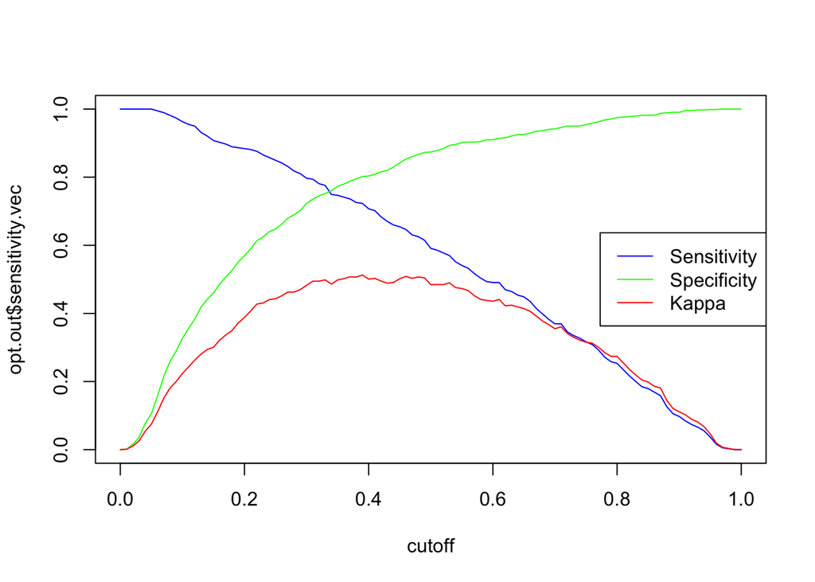

```r
step_kcv.out1 <- opt.cut.genn(step1_kcv, key.dummy(valid1))
opt.cut.plot(step_kcv.out1)
```

```r
#optimal by kappa score
step_kcv.out1$cutoff[which.max(step_kcv.out1$kappa.vec)]
```

```
## [1] 0.39
```

```r
#optimal by sensitivity/specificity balance
step_kcv.out1$cutoff[which.min(step_kcv.out1$ssdiff.vec)]
```

```
## [1] 0.34
```

Fit final model on combination of training and validation data

```r
set.seed(123)
# Fit K-fold CV model
bye4 <- capture.output(step1_kcv.final <- train(newgen ~ ., data = all.train1, family = "binomial",
                 method = "glmStepAIC", trControl = train_control, verbose = FALSE))
```

```r
step1_kcv.final <- step1_kcv.final$finalModel
summary(step1_kcv.final)
```

```
##
## Call:
## NULL
##
## Deviance Residuals:
##     Min       1Q   Median       3Q      Max
## -2.8352  -0.7137  -0.3909   0.7640   2.9907
##
## Coefficients:
##                   Estimate Std. Error z value Pr(>|z|)
## (Intercept)      -0.232605   0.359262  -0.647 0.517339
## popularity        0.078576   0.002264  34.703  < 2e-16 ***
## duration         -0.008557   0.001084  -7.891 3.00e-15 ***
## acousticness      0.742692   0.166217   4.468 7.89e-06 ***
## danceability      0.621269   0.322430   1.927 0.054000 .
## instrumentalness  2.523894   0.396667   6.363 1.98e-10 ***
## key1             -0.406358   0.104892  -3.874 0.000107 ***
## key4              0.286568   0.148288   1.933 0.053296 .
## key5             -0.213758   0.133258  -1.604 0.108695
## key6             -0.268144   0.131750  -2.035 0.041826 *
## key7             -0.153749   0.100404  -1.531 0.125696
## key8             -0.178777   0.120073  -1.489 0.136514
## loudness          0.178461   0.020387   8.754  < 2e-16 ***
## speechiness       0.991900   0.541126   1.833 0.066798 .
## valence          -0.673913   0.193922  -3.475 0.000511 ***
## ---
## Signif. codes:  0 '***' 0.001 '**' 0.01 '*' 0.05 '.' 0.1 ' ' 1
##
## (Dispersion parameter for binomial family taken to be 1)
##
##     Null deviance: 8158.1  on 6237  degrees of freedom
## Residual deviance: 5895.4  on 6223  degrees of freedom
## AIC: 5925.4
##
## Number of Fisher Scoring iterations: 5
```

Stepwise 10CV Logistic Model:

Energy, Key2, Key3, Key9, Key10, Key11, Energy and Tempo not included.

$$log(\frac{\hat \pi}{1 - \hat \pi}) = -0.233 + 0.079{Popularity} - 0.009{Duration} + 0.743{Acousticness} + 0.621{Danceability}
\\ + 2.524{Instrumentalness} - 0.406{Key1} + 0.287{Key4} - 0.214{Key5}
\\ - 0.268{Key6} - 0.154{Key7} - 0.179{Key8} + 0.178{Loudness}
\\ + 0.992{Speechiness} - 0.674{Valence}$$

The audio features in this model that increase the odds of being categorized as a new generation kpop song multiplicativley are Popularity, Acousticness, Danceability, Instrumentalness, Loudness, Speechiness, and choosing Key4(E Major) instead of Key0 (C Major). The features that decrease the odds multiplicatively of being categorized as a new generation kpop song are Duration, Valence and choosing, Key1(C#/D-flat Major), Key5(F Major), Key6(F#/G-flat Major), Key8(G#/A-flat Major), instead of Key0(C Major).

Only the variables Popularity, Duration, Acousticness, Instrumentalness, Loudness, Valence, and choosing Key1(C#/D-flat Major) or Key6(F#/G-flat Major) instead of Key0 (C Major) are significant predictors in contributing to the log of odds for categorizing a song into the newer generations of kpop versus the older generation for songs composed in the major mode.

Get prediction and performance evaluation for standard cut off 0.5

```r
#get predicted probabilities for the test data
step_kcv.test1.pred <- predict(step1_kcv.final, newdata = key.dummy(test1), type = "response")
step_kcv.test1.y <- ifelse(step_kcv.test1.pred > 0.5, 1, 0) # using cutoff = 0.5
confusionMatrix(as.factor(step_kcv.test1.y), as.factor(test1$newgen),
                positive = "1")
```

```
## Confusion Matrix and Statistics
##
##           Reference
## Prediction   0   1
##          0 594 160
##          1  96 251
##
##                Accuracy : 0.7675
##                  95% CI : (0.7414, 0.7921)
##     No Information Rate : 0.6267
##     P-Value [Acc > NIR] : < 2.2e-16
##
##                   Kappa : 0.4869
##
##  Mcnemar's Test P-Value : 8.233e-05
##
##             Sensitivity : 0.6107
##             Specificity : 0.8609
##          Pos Pred Value : 0.7233
##          Neg Pred Value : 0.7878
##              Prevalence : 0.3733
##          Detection Rate : 0.2280
##    Detection Prevalence : 0.3152
##       Balanced Accuracy : 0.7358
##
##        'Positive' Class : 1
##
```

Get prediction and performance evaluation for optimal cut off 0.39 for highest kappa

```r
#get predicted probabilities for the test data
step_kcv.test1.pred <- predict(step1_kcv.final, newdata = key.dummy(test1), type = "response")
step_kcv.test1.y <- ifelse(step_kcv.test1.pred > 0.39, 1, 0) # using cutoff = 0.39
confusionMatrix(as.factor(step_kcv.test1.y), as.factor(test1$newgen),
                positive = "1")
```

```
## Confusion Matrix and Statistics
##
##           Reference
## Prediction   0   1
##          0 543 118
##          1 147 293
##
##                Accuracy : 0.7593
##                  95% CI : (0.7329, 0.7843)
##     No Information Rate : 0.6267
##     P-Value [Acc > NIR] : < 2e-16
##
##                   Kappa : 0.4928
##
##  Mcnemar's Test P-Value : 0.08543
##
##             Sensitivity : 0.7129
##             Specificity : 0.7870
##          Pos Pred Value : 0.6659
##          Neg Pred Value : 0.8215
##              Prevalence : 0.3733
##          Detection Rate : 0.2661
##    Detection Prevalence : 0.3996
##       Balanced Accuracy : 0.7499
##
##        'Positive' Class : 1
##
```

Get prediction and performance evaluation for optimal cut off 0.34 for best sensitivity/specificity balance

```r
#get predicted probabilities for the test data
step_kcv.test1.pred <- predict(step1_kcv.final, newdata = key.dummy(test1), type = "response")
step_kcv.test1.y <- ifelse(step_kcv.test1.pred > 0.34, 1, 0) # using cutoff = 0.34
confusionMatrix(as.factor(step_kcv.test1.y), as.factor(test1$newgen),
                positive = "1")
```

```
## Confusion Matrix and Statistics
##
##           Reference
## Prediction   0   1
##          0 516  95
##          1 174 316
##
##                Accuracy : 0.7557
##                  95% CI : (0.7292, 0.7808)
##     No Information Rate : 0.6267
##     P-Value [Acc > NIR] : < 2.2e-16
##
##                   Kappa : 0.4974
##
##  Mcnemar's Test P-Value : 1.977e-06
##
##             Sensitivity : 0.7689
##             Specificity : 0.7478
##          Pos Pred Value : 0.6449
##          Neg Pred Value : 0.8445
##              Prevalence : 0.3733
##          Detection Rate : 0.2870
##    Detection Prevalence : 0.4450
##       Balanced Accuracy : 0.7583
##
##        'Positive' Class : 1
##
```

### Variable Selection: All possible regression

```r
set.seed(123)
glmulti.out1 <- glmulti(newgen ~ ., data = train1,
                           level = 1,               # No interaction considered
            method = "h",            # Exhaustive approach
            crit = "aic",            # AIC as criteria
            confsetsize = 5,         # Keep 5 best models
            plotty = F, report = F,  # No plot or interim reports
            fitfunction = "glm",     # lm function
            family = binomial)       # binomial to run logistic regression
glmulti.out1@formulas
```

```
## [[1]]
## newgen ~ 1 + key + popularity + duration + acousticness + danceability +
##     instrumentalness + loudness + valence
## <environment: 0x7ff77ff4dad8>
##
## [[2]]
## newgen ~ 1 + key + popularity + duration + acousticness + instrumentalness +
##     loudness + valence
## <environment: 0x7ff77ff4dad8>
##
## [[3]]
## newgen ~ 1 + key + popularity + duration + acousticness + danceability +
##     instrumentalness + loudness + speechiness + valence
## <environment: 0x7ff77ff4dad8>
##
## [[4]]
## newgen ~ 1 + key + popularity + duration + acousticness + danceability +
##     energy + instrumentalness + loudness + valence
## <environment: 0x7ff77ff4dad8>
##
## [[5]]
## newgen ~ 1 + key + popularity + duration + acousticness + instrumentalness +
##     loudness + speechiness + valence
## <environment: 0x7ff77ff4dad8>
```

view summary of top model

```r
summary(glmulti.out1@objects[[1]])
```

```
##
## Call:
## fitfunc(formula = as.formula(x), family = ..1, data = data)
##
## Deviance Residuals:
##     Min       1Q   Median       3Q      Max
## -2.8603  -0.7101  -0.3891   0.7640   2.9625
##
## Coefficients:
##                   Estimate Std. Error z value Pr(>|z|)
## (Intercept)      -0.174528   0.403868  -0.432 0.665639
## key1             -0.488374   0.135582  -3.602 0.000316 ***
## key2             -0.077569   0.140970  -0.550 0.582149
## key3              0.118963   0.224447   0.530 0.596093
## key4              0.112844   0.182502   0.618 0.536367
## key5             -0.271520   0.162560  -1.670 0.094865 .
## key6             -0.346110   0.161120  -2.148 0.031702 *
## key7             -0.200362   0.131369  -1.525 0.127213
## key8             -0.251743   0.151740  -1.659 0.097108 .
## key9              0.055155   0.164077   0.336 0.736754
## key10            -0.143506   0.195935  -0.732 0.463914
## key11            -0.235120   0.168610  -1.394 0.163179
## popularity        0.080283   0.002512  31.958  < 2e-16 ***
## duration         -0.008310   0.001199  -6.931 4.17e-12 ***
## acousticness      0.705422   0.181524   3.886 0.000102 ***
## danceability      0.526138   0.356026   1.478 0.139459
## instrumentalness  2.369217   0.466017   5.084 3.70e-07 ***
## loudness          0.169250   0.022608   7.486 7.09e-14 ***
## valence          -0.645666   0.212511  -3.038 0.002379 **
## ---
## Signif. codes:  0 '***' 0.001 '**' 0.01 '*' 0.05 '.' 0.1 ' ' 1
##
## (Dispersion parameter for binomial family taken to be 1)
##
##     Null deviance: 6738.9  on 5136  degrees of freedom
## Residual deviance: 4855.2  on 5118  degrees of freedom
## AIC: 4893.2
##
## Number of Fisher Scoring iterations: 5
```

Store model

```r
allreg.logit1 <- glmulti.out1@objects[[1]]
```

try fitting training data to results from all possible regression variable selection

```
#get predicted probabilities for training data
all.train1.pred <- allreg.logit1$fitted.values
all.train1.y <- ifelse(all.train1.pred > 0.5, 1, 0) # using cutoff = 0.5
confusionMatrix(as.factor(all.train1.y), as.factor(train1$newgen),
                positive = "1")
```

find optimal cut off value

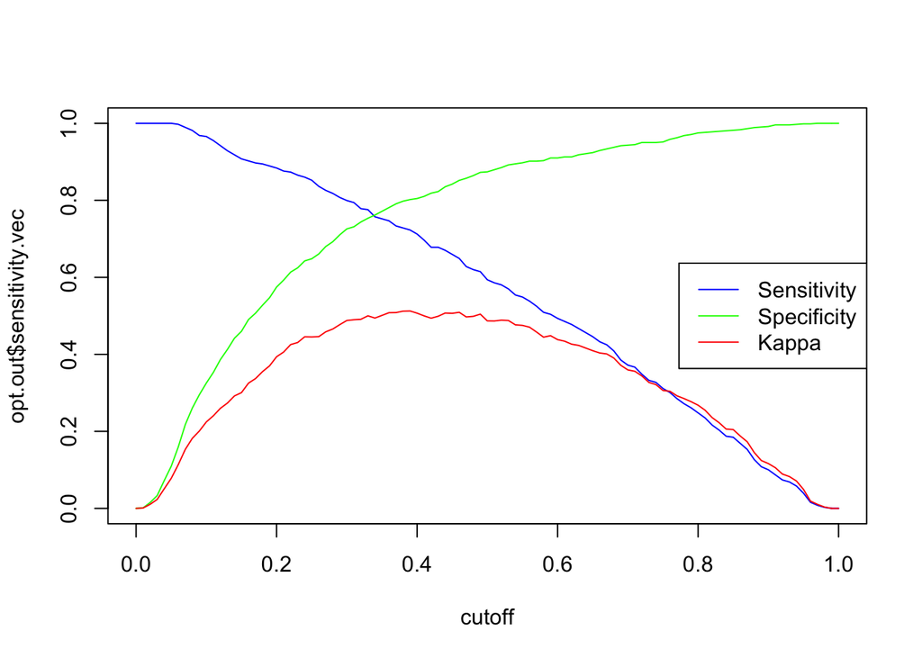

```r
allreg.out1 <- opt.cut.genn(allreg.logit1, valid1)
opt.cut.plot(allreg.out1)
```

```r
#optimal by kappa score
allreg.out1$cutoff[which.max(allreg.out1$kappa.vec)]
```

```
## [1] 0.39
```

```r
#optimal by sensitivity/specificity balance
allreg.out1$cutoff[which.min(allreg.out1$ssdiff.vec)]
```

```
## [1] 0.34
```

Fit final model on combo of train/validation data

```r
set.seed(123)
glmulti.out1.final <- glmulti(newgen ~ ., data = all.train1,
                           level = 1,               # No interaction considered
            method = "h",            # Exhaustive approach
            crit = "aic",            # AIC as criteria
            confsetsize = 5,         # Keep 5 best models
            plotty = F, report = F,  # No plot or interim reports
            fitfunction = "glm",     # lm function
            family = binomial)       # binomial to run logistic regression
glmulti.out1.final@formulas
```

```
## [[1]]
## newgen ~ 1 + key + popularity + duration + acousticness + danceability +
##     instrumentalness + loudness + speechiness + valence
## <environment: 0x7ff78d7db8d0>
##
## [[2]]
## newgen ~ 1 + key + popularity + duration + acousticness + danceability +
##     energy + instrumentalness + loudness + speechiness + valence
## <environment: 0x7ff78d7db8d0>
##
## [[3]]
## newgen ~ 1 + key + popularity + duration + acousticness + danceability +
##     energy + instrumentalness + loudness + valence
## <environment: 0x7ff78d7db8d0>
##
## [[4]]
## newgen ~ 1 + key + popularity + duration + acousticness + danceability +
##     instrumentalness + loudness + valence
## <environment: 0x7ff78d7db8d0>
##
## [[5]]
## newgen ~ 1 + key + popularity + duration + acousticness + instrumentalness +
##     loudness + speechiness + valence
## <environment: 0x7ff78d7db8d0>
```

```r
summary(glmulti.out1.final@objects[[1]])
```

```
##
## Call:
## fitfunc(formula = as.formula(x), family = ..1, data = data)
##
## Deviance Residuals:
##     Min       1Q   Median       3Q      Max
## -2.8350  -0.7108  -0.3916   0.7636   2.9929
##
## Coefficients:
##                   Estimate Std. Error z value Pr(>|z|)
## (Intercept)      -0.225784   0.367178  -0.615 0.538610
## key1             -0.415093   0.123488  -3.361 0.000775 ***
## key2              0.001643   0.127686   0.013 0.989736
## key3              0.146881   0.200396   0.733 0.463586
## key4              0.279109   0.162751   1.715 0.086356 .
## key5             -0.222002   0.148690  -1.493 0.135425
## key6             -0.276443   0.147164  -1.878 0.060317 .
## key7             -0.162392   0.119805  -1.355 0.175269
## key8             -0.187019   0.136815  -1.367 0.171640
## key9              0.002166   0.148954   0.015 0.988400
## key10            -0.071686   0.178289  -0.402 0.687626
## key11            -0.094143   0.153573  -0.613 0.539865
## popularity        0.078529   0.002266  34.650  < 2e-16 ***
## duration         -0.008588   0.001085  -7.913 2.52e-15 ***
## acousticness      0.739469   0.166784   4.434 9.26e-06 ***
## danceability      0.632472   0.322859   1.959 0.050116 .
## instrumentalness  2.516403   0.396780   6.342 2.27e-10 ***
## loudness          0.178352   0.020395   8.745  < 2e-16 ***
## speechiness       0.980171   0.541930   1.809 0.070503 .
## valence          -0.667741   0.194510  -3.433 0.000597 ***
## ---
## Signif. codes:  0 '***' 0.001 '**' 0.01 '*' 0.05 '.' 0.1 ' ' 1
##
## (Dispersion parameter for binomial family taken to be 1)
##
##     Null deviance: 8158.1  on 6237  degrees of freedom
## Residual deviance: 5894.0  on 6218  degrees of freedom
## AIC: 5934
##
## Number of Fisher Scoring iterations: 5
```

```r
allreg.logit1.final <- glmulti.out1.final@objects[[1]]
```

All Possible Regressions Model

Compared to the Full model, the one resulting from All possible Regressions omits Energy and Tempo.

$$log(\frac{\hat \pi}{1 - \hat \pi}) = -0.226 + 0.079{Popularity} - 0.009Duration + 0.739{Acousticness} + 0.632{Danceability}
\\ + 2.516{Instrumentalness} - 0.415{Key1} + 0.002{Key2}
\\ + 0.147{Key3} + 0.279{Key4} - 0.222{Key5} - 0.276{Key6} - 0.162{Key7}
\\ - 0.187{Key8} + 0.002{Key9} - 0.072{Key10} - 0.094{Key11} + 0.178{Loudness}
\\ + 0.980{Speechiness} - 0.668{Valence}$$

The audio features in this model that increase the odds of being categorized as a new generation kpop song multiplicativley are Popularity, Acousticness, Danceability, Instrumentalness, Loudness, Speechiness, and choosing Key2(D major), Key3(D#/E-flat Major), Key4(E Major), Key9(A Major), instead of Key0 (C Major). The features that decrease the odds multiplicatively of being categorized as a new generation kpop song are Duration, Valence and choosing, Key1(C#/D-flat Major), Key5(F Major), Key6(F#/G-flat Major), Key8 (G#/A-flat Major), Key10(A#/B-flat Major), Key11(B Major) instead of Key0(C Major).

Only the variables Popularity, Duration, Acousticness, Instrumentalness, Key1(C#/D-flat major), Loudness, and Valence are significant predictors in contributing to the log of odds for categorizing a song into the newer generations of kpop versus the older generation for songs composed in the major mode.

```r
#get predicted probabilities for the test data
all.test1.pred <- predict(allreg.logit1.final, newdata = test1, type = "response")
all.test1.y <- ifelse(all.test1.pred > 0.5, 1, 0) # using cutoff = 0.5
confusionMatrix(as.factor(all.test1.y), as.factor(test1$newgen),
                positive = "1")
```

```
## Confusion Matrix and Statistics
##
##           Reference
## Prediction   0   1
##          0 593 160
##          1  97 251
##
##                Accuracy : 0.7666
##                  95% CI : (0.7404, 0.7913)
##     No Information Rate : 0.6267
##     P-Value [Acc > NIR] : < 2e-16
##
##                   Kappa : 0.4852
##
##  Mcnemar's Test P-Value : 0.00011
##
##             Sensitivity : 0.6107
##             Specificity : 0.8594
##          Pos Pred Value : 0.7213
##          Neg Pred Value : 0.7875
##              Prevalence : 0.3733
##          Detection Rate : 0.2280
##    Detection Prevalence : 0.3161
##       Balanced Accuracy : 0.7351
##
##        'Positive' Class : 1
##
```

Using the cut off that yields the optimal kappa (0.39)

```r
#get predicted probabilities for the test data
all.test1.pred <- predict(allreg.logit1.final, newdata = test1, type = "response")
all.test1.y <- ifelse(all.test1.pred > 0.39, 1, 0) # using cutoff = 0.39
confusionMatrix(as.factor(all.test1.y), as.factor(test1$newgen),
                positive = "1")
```

```
## Confusion Matrix and Statistics
##
##           Reference
## Prediction   0   1
##          0 543 119
##          1 147 292
##
##                Accuracy : 0.7584
##                  95% CI : (0.732, 0.7834)
##     No Information Rate : 0.6267
##     P-Value [Acc > NIR] : < 2e-16
##
##                   Kappa : 0.4907
##
##  Mcnemar's Test P-Value : 0.09783
##
##             Sensitivity : 0.7105
##             Specificity : 0.7870
##          Pos Pred Value : 0.6651
##          Neg Pred Value : 0.8202
##              Prevalence : 0.3733
##          Detection Rate : 0.2652
##    Detection Prevalence : 0.3987
##       Balanced Accuracy : 0.7487
##
##        'Positive' Class : 1
##
```

Using the cut-off that yields the best balance between the sensitivity and specificity rates. (0.34)

```r
#get predicted probabilities for the test data
all.test1.pred <- predict(allreg.logit1.final, newdata = test1, type = "response")
all.test1.y <- ifelse(all.test1.pred > 0.34, 1, 0) # using cutoff = 0.34
confusionMatrix(as.factor(all.test1.y), as.factor(test1$newgen),
                positive = "1")
```

```
## Confusion Matrix and Statistics
##
##           Reference
## Prediction   0   1
##          0 516  94
##          1 174 317
##
##                Accuracy : 0.7566
##                  95% CI : (0.7301, 0.7817)
##     No Information Rate : 0.6267
##     P-Value [Acc > NIR] : < 2.2e-16
##
##                   Kappa : 0.4995
##
##  Mcnemar's Test P-Value : 1.395e-06
##
##             Sensitivity : 0.7713
##             Specificity : 0.7478
##          Pos Pred Value : 0.6456
##          Neg Pred Value : 0.8459
##              Prevalence : 0.3733
##          Detection Rate : 0.2879
##    Detection Prevalence : 0.4460
##       Balanced Accuracy : 0.7596
##
##        'Positive' Class : 1
##
```

### Regularized Regression: Ridge 10 fold Cross Validation

```r
set.seed(123)
ridge1 <- train(newgen ~ ., data = train1, method = "glmnet",
                      family = "binomial", trControl = train_control,
                      tuneGrid = expand.grid(alpha = 0,lambda = seq(0.001,0.1,by = 0.001)))
#best tuning parameter
ridge1$bestTune
```

```
##    alpha lambda
## 33     0  0.033
```

```r
ridge1.model <- coef(ridge1$finalModel, ridge1$bestTune$lambda)
ridge1.model
```

```
## 22 x 1 sparse Matrix of class "dgCMatrix"
##                              1
## (Intercept)      -0.4688373636
## popularity        0.0623432834
## duration         -0.0066895014
## acousticness      0.5232783706
## danceability      0.2773182924
## energy            0.2111190699
## instrumentalness  1.5004332358
## key1             -0.2842267079
## key2              0.0246794614
## key3              0.1981533232
## key4              0.1481008485
## key5             -0.1394070710
## key6             -0.1924983557
## key7             -0.0618183703
## key8             -0.0996685021
## key9              0.1261657234
## key10            -0.0506607181
## key11            -0.0859055968
## loudness          0.1161998271
## speechiness       0.7846248434
## tempo             0.0001524827
## valence          -0.4948676712
```

Search for best cutoff using validation set

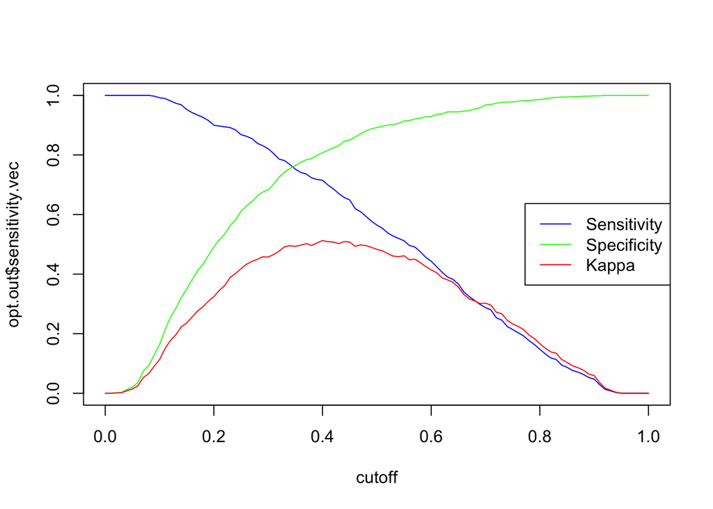

```r
ridge1.out <- reg.opt.cut.genn(ridge1, valid1)
opt.cut.plot(ridge1.out)
```

```r
# cut off by kappa
ridge1.out$cutoff[which.max(ridge1.out$kappa.vec)]
```

```
## [1] 0.4
```

```r
ridge1.out$cutoff[which.min(ridge1.out$ssdiff.vec)]
```

```
## [1] 0.35
```

create final model

```r
set.seed(123)
ridge1.final <- train(newgen ~ ., data = all.train1, method = "glmnet",
                      family = "binomial", trControl = train_control,
                      tuneGrid = expand.grid(alpha = 0,lambda = seq(0.001,0.1,by = 0.001)))
#best tuning parameter
ridge1.final$bestTune
```

```
##    alpha lambda
## 31     0  0.031
```

```r
ridge1.model.final <- coef(ridge1.final$finalModel, ridge1.final$bestTune$lambda)
ridge1.model.final
```

```
## 22 x 1 sparse Matrix of class "dgCMatrix"
##                              1
## (Intercept)      -5.377122e-01
## popularity        6.225805e-02
## duration         -7.082207e-03
## acousticness      5.526417e-01
## danceability      3.498383e-01
## energy            3.176845e-01
## instrumentalness  1.608579e+00
## key1             -2.565726e-01
## key2              6.434145e-02
## key3              2.052204e-01
## key4              2.560115e-01
## key5             -1.214950e-01
## key6             -1.623573e-01
## key7             -5.643156e-02
## key8             -7.132447e-02
## key9              6.796932e-02
## key10            -2.519994e-02
## key11            -1.078875e-02
## loudness          1.171341e-01
## speechiness       9.146757e-01
## tempo             4.967093e-05
## valence          -5.018414e-01
```

The audio features in this model that increase the odds of being categorized as a new generation kpop song multiplicativley are Popularity, Acousticness, Danceability, Energy, Instrumentalness, Loudness, Speechiness, Tempo and choosing Key2(D major), Key3(D#/E-flat Major), Key4(E Major), Key9(A Major), instead of Key0 (C Major). The features that decrease the odds multiplicatively of being categorized as a new generation kpop song are Duration, Valence and choosing, Key1(C#/D-flat Major), Key5(F Major), Key6(F#/G-flat Major), Key8 (G#/A-flat Major), Key10(A#/B-flat Major), Key11(B Major) instead of Key0(C Major).

predict and evaluate on the test set where cutoff is at 0.5

```r
prob.ridge1 <- predict(ridge1.final, s = ridge1.final$bestTune, test1, type = "prob")
pred.ridge1 <- ifelse(prob.ridge1[,2] > 0.50, 1, 0) # using cutoff = 0.5
confusionMatrix(as.factor(pred.ridge1), as.factor(test1$newgen),
                positive = "1")
```

```
## Confusion Matrix and Statistics
##
##           Reference
## Prediction   0   1
##          0 603 172
##          1  87 239
##
##                Accuracy : 0.7648
##                  95% CI : (0.7386, 0.7895)
##     No Information Rate : 0.6267
##     P-Value [Acc > NIR] : < 2.2e-16
##
##                   Kappa : 0.4753
##
##  Mcnemar's Test P-Value : 1.794e-07
##
##             Sensitivity : 0.5815
##             Specificity : 0.8739
##          Pos Pred Value : 0.7331
##          Neg Pred Value : 0.7781
##              Prevalence : 0.3733
##          Detection Rate : 0.2171
##    Detection Prevalence : 0.2961
##       Balanced Accuracy : 0.7277
##
##        'Positive' Class : 1
##
```

predict and evaluate on the test set where cutoff is at 0.40 corresponding to optimal kappa

```r
prob.ridge1 <- predict(ridge1.final, s = ridge1.final$bestTune, test1, type = "prob")
pred.ridge1 <- ifelse(prob.ridge1[,2] > 0.40, 1, 0) # using cutoff = 0.40
confusionMatrix(as.factor(pred.ridge1), as.factor(test1$newgen),
                positive = "1")
```

```
## Confusion Matrix and Statistics
##
##           Reference
## Prediction   0   1
##          0 555 121
##          1 135 290
##
##                Accuracy : 0.7675
##                  95% CI : (0.7414, 0.7921)
##     No Information Rate : 0.6267
##     P-Value [Acc > NIR] : <2e-16
##
##                   Kappa : 0.5065
##
##  Mcnemar's Test P-Value : 0.4165
##
##             Sensitivity : 0.7056
##             Specificity : 0.8043
##          Pos Pred Value : 0.6824
##          Neg Pred Value : 0.8210
##              Prevalence : 0.3733
##          Detection Rate : 0.2634
##    Detection Prevalence : 0.3860
##       Balanced Accuracy : 0.7550
##
##        'Positive' Class : 1
##
```

predict and evaluate on the test set where cutoff is at 0.35 corresponding to optimal balance of sensitivity and specificity

```r
prob.ridge1 <- predict(ridge1.final, s = ridge1.final$bestTune, test1, type = "prob")
pred.ridge1 <- ifelse(prob.ridge1[,2] > 0.35, 1, 0) # using cutoff = 0.35
confusionMatrix(as.factor(pred.ridge1), as.factor(test1$newgen),
                positive = "1")
```

```
## Confusion Matrix and Statistics
##
##           Reference
## Prediction   0   1
##          0 518  96
##          1 172 315
##
##                Accuracy : 0.7566
##                  95% CI : (0.7301, 0.7817)
##     No Information Rate : 0.6267
##     P-Value [Acc > NIR] : < 2.2e-16
##
##                   Kappa : 0.4985
##
##  Mcnemar's Test P-Value : 4.62e-06
##
##             Sensitivity : 0.7664
##             Specificity : 0.7507
##          Pos Pred Value : 0.6468
##          Neg Pred Value : 0.8436
##              Prevalence : 0.3733
##          Detection Rate : 0.2861
##    Detection Prevalence : 0.4423
##       Balanced Accuracy : 0.7586
##
##        'Positive' Class : 1
##
```

### Regularized Regression: Lasso 10 fold Cross Validation

```r
set.seed(123)
lasso1 <- train(newgen ~ ., data = train1, method = "glmnet",
                      family = "binomial", trControl = train_control,
                      tuneGrid = expand.grid(alpha = 1,lambda = seq(0.001,0.1,by = 0.001)))
# best parameter
lasso1$bestTune
```

```
##    alpha lambda
## 10     1   0.01
```

```r
# best coefficient
lasso1.model <- coef(lasso1$finalModel, lasso1$bestTune$lambda)
lasso1.model
```

```
## 22 x 1 sparse Matrix of class "dgCMatrix"
##                             1
## (Intercept)      -0.927911611
## popularity        0.075011921
## duration         -0.005906046
## acousticness      0.194746828
## danceability      .
## energy            .
## instrumentalness  1.168936964
## key1             -0.172825775
## key2              .
## key3              .
## key4              0.001909741
## key5              .
## key6              .
## key7              .
## key8              .
## key9              .
## key10             .
## key11             .
## loudness          0.080633387
## speechiness       .
## tempo             .
## valence          -0.098005119
```

Search for best cutoff using validation set

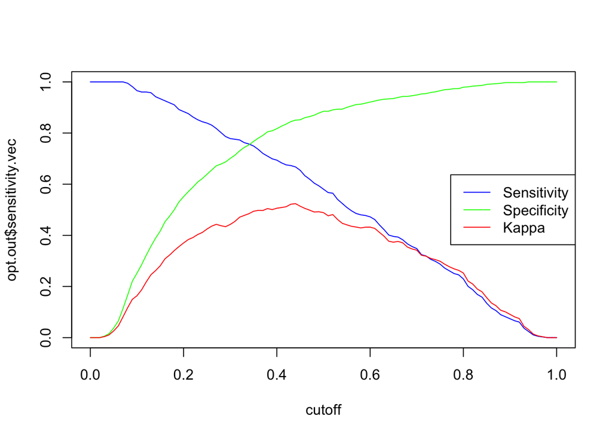

```r
lasso1.out <- reg.opt.cut.genn(lasso1, valid1)
opt.cut.plot(lasso1.out)
```

```r
# cut off by kappa
lasso1.out$cutoff[which.max(lasso1.out$kappa.vec)]
```

```
## [1] 0.44
```

```r
lasso1.out$cutoff[which.min(lasso1.out$ssdiff.vec)]
```

```
## [1] 0.34
```

create final model

```r
set.seed(123)
lasso1.final <- train(newgen ~ ., data = train1, method = "glmnet",
                      family = "binomial", trControl = train_control,
                      tuneGrid = expand.grid(alpha = 1,lambda = seq(0.001,0.1,by = 0.001)))
# best parameter
lasso1.final$bestTune
```

```
##    alpha lambda
## 10     1   0.01
```

```r
# best coefficient
lasso1.model.final <- coef(lasso1.final$finalModel, lasso1.final$bestTune$lambda)
lasso1.model.final
```

```
## 22 x 1 sparse Matrix of class "dgCMatrix"
##                             1
## (Intercept)      -0.927911611
## popularity        0.075011921
## duration         -0.005906046
## acousticness      0.194746828
## danceability      .
## energy            .
## instrumentalness  1.168936964
## key1             -0.172825775
## key2              .
## key3              .
## key4              0.001909741
## key5              .
## key6              .
## key7              .
## key8              .
## key9              .
## key10             .
## key11             .
## loudness          0.080633387
## speechiness       .
## tempo             .
## valence          -0.098005119
```

Lasso 10 Fold Cross Validation Logistic model:

Compared to the full logistic model the lasso model does not include the variables Danceability, Energy, Key2, Key3, Key5 - Key11, Speechiness, and Tempo.

$$log(\frac{\hat \pi}{1 - \hat \pi}) = -0.928 + 0.075{Popularity} - 0.006{Duration} + 0.195{Acousticness}
\\ + 1.169{Instrumentalness} - 0.173{Key1} + 0.002{Key4} + 0.081{Loudness} - 0.098{Valence}$$

The audio features in this model that increase the odds of being categorized as a new generation kpop song multiplicativley are Popularity, Acousticness, Instrumentalness, Loudness, and choosing Key4(E Major) instead of Key0 (C Major). The features that decrease the odds multiplicatively of being categorized as a new generation kpop song are Duration, Valence and choosing, Key1(C#/D-flat) instead of Key0(C Major).

predict and evaluate on the test set where cutoff is at 0.5

```r
prob.lasso1 <- predict(lasso1.final, s = lasso1.final$bestTune, test1, type = "prob")
pred.lasso1 <- ifelse(prob.lasso1[,2] > 0.50, 1, 0) # using cutoff = 0.5
confusionMatrix(as.factor(pred.lasso1), as.factor(test1$newgen),
                positive = "1")
```

```
## Confusion Matrix and Statistics
##
##           Reference
## Prediction   0   1
##          0 603 166
##          1  87 245
##
##                Accuracy : 0.7702
##                  95% CI : (0.7442, 0.7948)
##     No Information Rate : 0.6267
##     P-Value [Acc > NIR] : < 2.2e-16
##
##                   Kappa : 0.489
##
##  Mcnemar's Test P-Value : 9.399e-07
##
##             Sensitivity : 0.5961
##             Specificity : 0.8739
##          Pos Pred Value : 0.7380
##          Neg Pred Value : 0.7841
##              Prevalence : 0.3733
##          Detection Rate : 0.2225
##    Detection Prevalence : 0.3015
##       Balanced Accuracy : 0.7350
##
##        'Positive' Class : 1
##
```

predict and evaluate on the test set where cutoff is at 0.44 corresponding to optimal kappa

```r
prob.lasso1 <- predict(lasso1.final, s = lasso1.final$bestTune, test1, type = "prob")
pred.lasso1 <- ifelse(prob.lasso1[,2] > 0.44, 1, 0) # using cutoff = 0.44
confusionMatrix(as.factor(pred.lasso1), as.factor(test1$newgen),
                positive = "1")
```

```
## Confusion Matrix and Statistics
##
##           Reference
## Prediction   0   1
##          0 582 140
##          1 108 271
##
##                Accuracy : 0.7748
##                  95% CI : (0.7489, 0.7991)
##     No Information Rate : 0.6267
##     P-Value [Acc > NIR] : < 2e-16
##
##                   Kappa : 0.5109
##
##  Mcnemar's Test P-Value : 0.04901
##
##             Sensitivity : 0.6594
##             Specificity : 0.8435
##          Pos Pred Value : 0.7150
##          Neg Pred Value : 0.8061
##              Prevalence : 0.3733
##          Detection Rate : 0.2461
##    Detection Prevalence : 0.3442
##       Balanced Accuracy : 0.7514
##
##        'Positive' Class : 1
##
```

predict and evaluate on the test set where cutoff is at 0.34 corresponding to optimal balance of sensitivity and specificity

```r
prob.lasso1 <- predict(lasso1.final, s = lasso1.final$bestTune, test1, type = "prob")
pred.lasso1 <- ifelse(prob.lasso1[,2] > 0.34, 1, 0) # using cutoff = 0.34
confusionMatrix(as.factor(pred.lasso1), as.factor(test1$newgen),
                positive = "1")
```

```
## Confusion Matrix and Statistics
##
##           Reference
## Prediction   0   1
##          0 515  98
##          1 175 313
##
##                Accuracy : 0.752
##                  95% CI : (0.7254, 0.7773)
##     No Information Rate : 0.6267
##     P-Value [Acc > NIR] : < 2.2e-16
##
##                   Kappa : 0.4894
##
##  Mcnemar's Test P-Value : 4.23e-06
##
##             Sensitivity : 0.7616
##             Specificity : 0.7464
##          Pos Pred Value : 0.6414
##          Neg Pred Value : 0.8401
##              Prevalence : 0.3733
##          Detection Rate : 0.2843
##    Detection Prevalence : 0.4432
##       Balanced Accuracy : 0.7540
##
##        'Positive' Class : 1
##
```

### Regularized Regression: Elastic Net 10 fold Cross Validation

```r
set.seed(123)
enet1 <- train(newgen ~ ., data = train1, method = "glmnet",
                      family = "binomial", trControl = train_control,
                      tuneGrid = expand.grid(alpha = seq(0,1,by = 0.05),lambda = seq(0.001,0.1,by = 0.001)))
# best parameter
enet1$bestTune
```

```
##      alpha lambda
## 1116  0.55  0.016
```

```r
# best coefficient
enet1.model <- coef(enet1$finalModel, enet1$bestTune$lambda)
enet1.model
```

```
## 22 x 1 sparse Matrix of class "dgCMatrix"
##                             1
## (Intercept)      -0.738321081
## popularity        0.071079680
## duration         -0.006022378
## acousticness      0.228043631
## danceability      .
## energy            .
## instrumentalness  1.132790510
## key1             -0.175979888
## key2              .
## key3              .
## key4              0.011982808
## key5              .
## key6             -0.006475829
## key7              .
## key8              .
## key9              .
## key10             .
## key11             .
## loudness          0.086884669
## speechiness       .
## tempo             .
## valence          -0.153118527
```

search for best cutoff with validation set

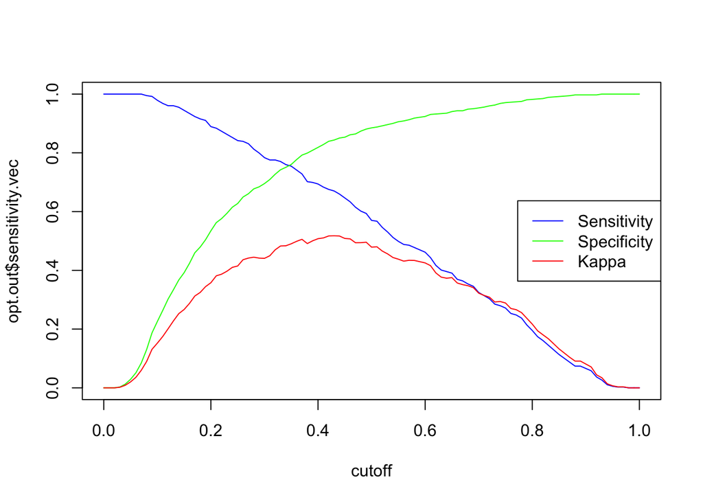

```r
enet1.out <- reg.opt.cut.genn(enet1, valid1)
opt.cut.plot(enet1.out)
```

```r
# cut off by kappa
enet1.out$cutoff[which.max(enet1.out$kappa.vec)]
```

```
## [1] 0.43
```

```r
enet1.out$cutoff[which.min(enet1.out$ssdiff.vec)]
```

```
## [1] 0.35
```

create final model on train and validation

```r
set.seed(123)
enet1.final <- train(newgen ~ ., data = all.train1, method = "glmnet",
                      family = "binomial", trControl = train_control,
                      tuneGrid = expand.grid(alpha = seq(0,1,by = 0.05),lambda = seq(0.001,0.1,by = 0.001)))
# best parameter
enet1.final$bestTune
```

```
##      alpha lambda
## 1916  0.95  0.016
```

```r
# best coefficient
enet1.model.final <- coef(enet1.final$finalModel, enet1.final$bestTune$lambda)
enet1.model.final
```

```
## 22 x 1 sparse Matrix of class "dgCMatrix"
##                             1
## (Intercept)      -1.072014644
## popularity        0.071103334
## duration         -0.005421348
## acousticness      .
## danceability      .
## energy            .
## instrumentalness  0.671489139
## key1             -0.058775458
## key2              .
## key3              .
## key4              .
## key5              .
## key6              .
## key7              .
## key8              .
## key9              .
## key10             .
## key11             .
## loudness          0.054004824
## speechiness       .
## tempo             .
## valence           .
```

Elastic Net 10 Fold Cross Validation Logistic model:

The audio features in this model that increase the odds of being categorized as a new generation kpop song multiplicativley are Popularity, Instrumentalness, and Loudness. The features that decrease the odds multiplicatively of being categorized as a new generation kpop song are Duration and choosing Key1(C#/D-flat) instead of Key0(C Major).

predict and evaluate on the test set where cutoff is at 0.5

```r
prob.enet1 <- predict(enet1.final, s = enet1.final$bestTune, test1, type = "prob")
pred.enet1 <- ifelse(prob.enet1[,2] > 0.50, 1, 0) # using cutoff = 0.5
confusionMatrix(as.factor(pred.enet1), as.factor(test1$newgen),
                positive = "1")
```

```
## Confusion Matrix and Statistics
##
##           Reference
## Prediction   0   1
##          0 605 165
##          1  85 246
##
##                Accuracy : 0.7729
##                  95% CI : (0.747, 0.7974)
##     No Information Rate : 0.6267
##     P-Value [Acc > NIR] : < 2.2e-16
##
##                   Kappa : 0.4948
##
##  Mcnemar's Test P-Value : 5.841e-07
##
##             Sensitivity : 0.5985
##             Specificity : 0.8768
##          Pos Pred Value : 0.7432
##          Neg Pred Value : 0.7857
##              Prevalence : 0.3733
##          Detection Rate : 0.2234
##    Detection Prevalence : 0.3006
##       Balanced Accuracy : 0.7377
##
##        'Positive' Class : 1
##
```

predict and evaluate on the test set where cutoff is at 0.43 corresponding to optimal kappa

```r
prob.enet1 <- predict(enet1.final, s = enet1.final$bestTune, test1, type = "prob")
pred.enet1 <- ifelse(prob.enet1[,2] > 0.43, 1, 0) # using cutoff = 0.43
confusionMatrix(as.factor(pred.enet1), as.factor(test1$newgen),
                positive = "1")
```

```
## Confusion Matrix and Statistics
##
##           Reference
## Prediction   0   1
##          0 585 137
##          1 105 274
##
##                Accuracy : 0.7802
##                  95% CI : (0.7546, 0.8043)
##     No Information Rate : 0.6267
##     P-Value [Acc > NIR] : < 2e-16
##
##                   Kappa : 0.5227
##
##  Mcnemar's Test P-Value : 0.04629
##
##             Sensitivity : 0.6667
##             Specificity : 0.8478
##          Pos Pred Value : 0.7230
##          Neg Pred Value : 0.8102
##              Prevalence : 0.3733
##          Detection Rate : 0.2489
##    Detection Prevalence : 0.3442
##       Balanced Accuracy : 0.7572
##
##        'Positive' Class : 1
##
```

predict and evaluate on the test set where cutoff is at 0.35 corresponding to optimal balance of sensitivity and specificity

```r
prob.enet1 <- predict(enet1.final, s = enet1.final$bestTune, test1, type = "prob")
pred.enet1 <- ifelse(prob.enet1[,2] > 0.35, 1, 0) # using cutoff = 0.35
confusionMatrix(as.factor(pred.enet1), as.factor(test1$newgen),
                positive = "1")
```

```
## Confusion Matrix and Statistics
##
##           Reference
## Prediction   0   1
##          0 525 103
##          1 165 308
##
##                Accuracy : 0.7566
##                  95% CI : (0.7301, 0.7817)
##     No Information Rate : 0.6267
##     P-Value [Acc > NIR] : < 2.2e-16
##
##                   Kappa : 0.4952
##
##  Mcnemar's Test P-Value : 0.0001944
##
##             Sensitivity : 0.7494
##             Specificity : 0.7609
##          Pos Pred Value : 0.6512
##          Neg Pred Value : 0.8360
##              Prevalence : 0.3733
##          Detection Rate : 0.2797
##    Detection Prevalence : 0.4296
##       Balanced Accuracy : 0.7551
##
##        'Positive' Class : 1
##
```

### Deciding on the best model for Mode 1 songs

Performance metrics

```r
mode1.results <- data.frame(Model = c("Full", "Step", "Step 10CV", "AllReg", "Ridge 10CV", "Lasso 10CV", "ElasticNet 10CV"),
                            cutoff = c(0.34, 0.34, 0.34, 0.34, 0.35, 0.34, 0.35), #Best balance between sensitivity and specificity
                            AIC = c(5936.1, 5934, 5925.4, 5934, NA, NA, NA),
                            Accuracy = c(0.7575, 0.7566, 0.7557, 0.7566, 0.7566, 0.7520, 0.7566),
                            Kappa = c(0.5006, 0.4995, 0.4974, 0.4995, 0.4985, 0.4894, 0.4952),
                            Sensitivity = c(0.7689, 0.7713, 0.7689, 0.7713, 0.7664, 0.7616, 0.7494),
                            Specificity = c(0.7507, 0.7478, 0.7478, 0.7478, 0.7507, 0.7464, 0.7609))
mode1.results
```

```
##             Model cutoff    AIC Accuracy  Kappa Sensitivity Specificity
## 1            Full   0.34 5936.1   0.7575 0.5006      0.7689      0.7507
## 2            Step   0.34 5934.0   0.7566 0.4995      0.7713      0.7478
## 3       Step 10CV   0.34 5925.4   0.7557 0.4974      0.7689      0.7478
## 4          AllReg   0.34 5934.0   0.7566 0.4995      0.7713      0.7478
## 5      Ridge 10CV   0.35     NA   0.7566 0.4985      0.7664      0.7507
## 6      Lasso 10CV   0.34     NA   0.7520 0.4894      0.7616      0.7464
## 7 ElasticNet 10CV   0.35     NA   0.7566 0.4952      0.7494      0.7609
```

The best model is the full logistic model.

Full Logistic model

$$log(\frac{\hat \pi}{1 - \hat \pi}) = -0.783 + 0.079{Popularity} - 0.009{Duration} + 0.882{Acousticness} + 0.665{Danceability}
\\ + 0.537{Energy} + 2.471{Instrumentalness} - 0.415{Key1} + 0.002{Key2}
\\ + 0.149{Key3} + 0.280{Key4} - 0.217{Key5} - 0.280{Key6} - 0.161{Key7}
\\ - 0.185{Key8} + 0.006{Key9} - 0.071{Key10} - 0.094{Key11} + 0.154{Loudness}
\\ + 0.792{Speechiness} + 0.0002{Tempo} - 0.742{Valence}$$